# Towards Trustworhy Deep Learning for Breast Cancer Detection

## A Calibration and Uncertainty-Aware Mammography Classification Framework

#### Marcela Lakhwani Nathani || Final Project (CM3070)

### Introduction

Breast cancer is a major application area for medical image analysis, and mammography remains an important imaging modality for detecting and assessing suspicious breast abnormalities. Deep-learning methods have demonstrated considerable potential for analysing medical images; however, evaluating a model intended to support medical decision-making requires more than measuring classification accuracy. Its predicted probabilities should also be evaluated for calibration, uncertainty and interpretability.

Probability calibration measures whether a model's reported confidence corresponds to its observed likelihood of being correct. This is important because modern neural networks can produce high-confidence predictions even when those predictions are incorrect. Guo et al. demonstrated that strong classification performance does not necessarily imply well-calibrated probabilities and identified temperature scaling as an effective post-hoc calibration method [1].

This project develops and evaluates a deep-learning framework for binary breast abnormality classification using the Curated Breast Imaging Subset of the Digital Database for Screening Mammography (CBIS-DDSM). CBIS-DDSM is a standardised and curated version of the original DDSM collection containing mammographic cases with associated pathology information, abnormality metadata, cropped lession images and region-of-interest annotations [2].

The primary prediction task is to classify a cropped mammographic abnormality as:

- Benign, representing a non-cancerous finding.
- Malignant, representing a cancerous finding.

The framework compares a custom convolutional neural network with a transfer-learning approach based on EfficientNetBO. EfficientNet architectures use compound scaling to balance network depth, width and input resolution [3]. EfficientNetV2BO is additionally evaluatted as a controlled post-hoc architectural comparison because the EfficientNetV2 family was developed to improve training speed and parameter efficiency [4].

Beyond conventional classification performance, the evaluation considers:

- probability calibration;
- uncertainty estimation;
- selective prediction;
- subgroup performance;
- model explainability using Grad-CAM;
- quantitative Grad-CAM localisation for cases with usable lesion marks.

Monte Carlo dropout is used to estimate predictive uncertainty through repeated stochastic forward passes, following the interpretation of dropout as an approximation to Bayesian interference [5]. Selective prediction is then investifated by allowing the model to abstain from making predictions on cases associated with greater uncertainty. This creates a trade-off between coverage and predictive performance, as described in selective-classification research [6].

Grad-CAM is used to generate visual explanations by identifying spatial regions within an image that contribute to a convolutional neural network's prediction [7]. Where usable lesion annotations are available, these explanations are also compared quantitatively with the annotated lesion regions.

The objective is therefore not only to determine whether the model can distinguish benign from malignant abnormalities, but also to investigate whether its probability estimates are reliable, whether uncertain predictions can be identified and whether its visual explanations correspond to annotated lesion regions.

### 1.2 Inclusion of Calcification and Masses

Restricting the study to masses alone would create a narrower classification problem and would not represent the range of abnormalities available in CBIS-DDSM. The dataset contains both mass and calcification cases, together with pathology labels and lesion-related metadata [2].

Calcifications and masses differ in several important characteristics, including:

- physical appearance;
- lesion size;
- texture;
- boundary characteristics;
- diagnostic features;
- sensitivity to image preprocessing

Mass assessment often depends on characteristics such as shape, density and margins, whereas calcification assesment can depend on the morphology and distribution of much smaller image patterns. Including both abnormality types therefore creates a more comprehensive lesion-level classification problem.

The model is not trained to predict whether an abnormality is a calcification or a mass. Instead, abnormality type is retained as a subgroup variable, while the prediction target remains benign versus malignant.

This design allows the study to investigate two related questions:

1. How accurately can the model classify abnormalities as benign or malignant across the combined dataset?
2. Does classification performance differ between calcification and mass subgroups?

The second question is important because aggregate performance can conceal weaker performance within a clinically meaningful subgroup. Subgroup evaluation therefore provides a more detailed account of model behaviour than overall performance metrics alone.

### 1.3 Study Design

The experimental workflow consists of the following stages:

1. Load and standardise the CBIS-DDSM metadata.
2. Combine the calcification and mass records.
3. Convert the pathology laels into a binary classification target.
4. Construct patinet-independent training, validation and test partitions.
5. Resolve metadata records to the corresponding DICOM lesion images.
6. Preprocess and normalise the images.
7. Construct reproducible TensorFlow input pipelines.
8. Train a custom baseline convolutional neural network.
9. Train an EfficientNetBO model using transfer learning.
10. Fine-tune selected layers of the EfficientNetBO model.
11. Compare the candidate models using validation performance.
12. Conduct a controlled, validation-only comparison with EfficientNetV2BO.
13. Retain the primary model according to the predefined validation ROC-AUC criterion.
14. Evaluate the retained EfficientNetBO model once on the held-out test partition.
15. Assess deiscrimination using ROC-AUC, PR-AUC, sensitivity, specificity and related classification metrics.
16. Assess probability calibration using reliability diagrams, Expected Calibration Error, Brier score and negative log-likelihood.
17. Fit a temperature-scaling parameter using the validation partition and evaluate the resulting calibrated probabilities.
18. Estimate predictive uncertainty using Monte Carlo dropout.
19. Evaluate selective prediction by allowing the model to abstain from uncertain cases.
20. Compare classification performance between calcification and mass subgroups.
21. Generate Grad-CAM visualisations to examine the image regions influencing individual predictions.
22. Quantitatively evaluate Grad-CAM localisation for test cases with successfully resolved lesion masks.
23. Consolidate the principal classification, calibration, uncertainty and explainability findings.

The EfficientNetV2BO experiment is treated as an additional post-hoc comparison. It uses the same patient partitions, image-processing pipeline, augmentation strategy, class-weighting approach and primary validation metric as the EfficientNetBO experiment. Because EfficientNetV2BO did not improve the predefined validation ROC-AUC criterion, EfficientNetBO remains the primary model and EfficientNetV2BO is not evaluated on the held-out test partition.

A fixed probability threshold of 0.5 is used to convert predicted probabilities into binary class predictions. This threshold is not optimised using the test partition.

### 1.4 Research Objectives

The main objectives of this implementation are:

- To develop a reproducible lesion-level mammography classification pipeline;
- To prevent patient-level information leakage through grouped data partitioning;
- To compare a custom baseline CNN with an EfficientNetBO transfer-learning model;
- To conduct an additional controlled comparison with EfficientNetV2BO;
- To evaluate classification performance separately for calcification and mass abnormalities;
- To investigate the reliability of predicted probabilities;
- To improve probability calibration using post-hoc temperature scaling;
- To identify predictions associated with greater uncertainty;
- To assess the trade-off between coverage and predictive performance through selective prediction;
- To generate visual explanations using Grad-CAM;
- To quantitatively assess Grad-CAM localisation for mass cases with usable lesion annotations.

### 1.5 Research Questions

The primary research question is:

> Can a deep-learning model distinguish benign from malignant mammographic abnormalities while producing calibrated probabilities, identifying uncertain predictions and providing interpretable image-based explanations?

The supporting research questions are:

- Which evaluated architecture provides the strongest discrimination on the validation partition?
- How well does the selected model perform on the held-out test partition?
- Are the model's predicted probabilities well calibrated?
- Does probability calibration improve after temperature scaling?
- Does classification performance differ between calcification and mass cases?
- Can Monte Carlo dropout uncertainty estimates identify less reliable predictions?
- Does selective prediction improve performance when uncertain cases are excluded?
- Do Grad-CAM visualisations highlight the regions containing annotated mass lesions?

These questions separate classification performance from probability reliability and explanation quality. This distinction is important because a model may classify cases correctly cases correctly while still producing poorly calibrated confidence estimates or visually implausible explanations.

### 1.6 Unit of Analysis

The unit of analysis is the cropped mammographic abnormality image.

Each record represents an abnormality identified in the CBIS-DDSM metadata. A patient may contribute more than one record because:

- Both craniocaudal and mediolateral oblique views may be available;
- Multiple abnormalities may be present in the same breast;
- An abnormality may have associated cropped images and ROI masks.

Because multiple records can originate from the same patient, performing an image-level random split could place related observations in different dataset partitions. This would introduce information leakage and could produce overly optimistic performance estimates.

Dataset partitioning is therefore performed at the patient level. All records associated with the same patient are assigned to only one of the training, validation or test partitions.

The resulting performance estimates are lesion-image-level results. They should not be interpreted as patient-level diagnostic performance because the framework classifies individual cropped abnormality images rather than complete patient examinations.

### 1.7 Classification Target

The original pathology labels are converted into a binary classification target as follows:

| Original pathology label | Binary target |
| --- | --- |
| BENIGN | 0 |
| BENIGN_WITHOUT_CALLBACK | 0 |
| MALIGNANT | 1 |

The positive class is defined as malignant because the principal classification objective is to identify cancerous abnormalities,

Abnormality type - calcification or mass - is retained separately for subgroup evaluation but is not used as the prediction target. Consequently, the model is trained to distinguish benign from malignant findings across both abnormality groups.

### 1.8 Scope of Interpretation

This project provides an internal technical evaluation using patient-independent partitions derived from CBIS-DDSM. The held-out test partition is isolated from model fitting, model selection, temperature-scaling estimation and the EfficientNetV2BO comparison.

However, an internal held-out test partition does not establish that the model will generalise to images collected at other institutions or using different imaging equipment, acquisition protocols and patient populations. External validation using an independent mammography dataset would therefore be required before making broader claims about generalisability. Guidance for reporting medical-imaging AI studies similarly highlights transparent data partitioning, explainability evaluation and external testing as important considerations [8].

No radiologist or other clinical domain expert participated in evaluating the clinical usefulness of the model predictions, uncertainty estimates or Grad-CAM explanations. The findings should therefore be interpreted as a technical assessment rather than evidence of clinical validity or suitability for deployment.

Classification performance and subgroup behaviour are evaluated for both calcification and masses. However, quantitative Grad-CAM localisation is restricted to mass cases for which lesion masks were successfully resolved. Calcification masks could not be resolved reliability using the available file mapping and were excluded from the quantitative localisation analysis.

The Grad-CAM localisation results should therefore be interpreted as evidence concerning mass lesions only and should not be generalised to calcification abnormalities. External dataset validation, quantitative localisation for calcification cases and assessment by radiologists remain important directions for future work.

### 2. Experimental Environment and Reproducibility

This section configures the computational environment and common experimental settings used throuhout the project.

Deep-learning experiments contain several sources of randomness, including model-weight initialisation, data shuffling, augmentation and stochastic optimisation. Global random seeds are therefore applied to Python, NumPy and TensorFlow to improve reproducibility across repeated executions.

The principal configuration values, including image dimensions, batch size, random seed and dataset paths, are defined centrally to reduce duplication and prevent inconsistent settings across later notebook sections. Although these measures improve reproducibility, identical results are not guaranteed across different hardware, software versions or TensorFlow execution environments.

### 2.1 Library Imports

The implementation uses:

- Pandas and Numpy for metadata processing and numerical operations.
- Matplotlib and Seaborn for exploratory analysis and evaluation figures.
- Pydicom for reading and processing mammography DICOM files.
- Scikit-learn for patient-level data partitioning and performance metrics.
- TensorFlow/Keras for image pipelines, data augmentation and deep-learning models.
- SciPy for statistical calculations and calibration-related optimisation.
- TQDM for progress monitoring during image-path and annotation resolution.

```python
#STANDARD LIBRARY IMPORTS
#provides access to operating-system functionality, including environment variables and file-path operations.
import os

#Supports regular-expression matching for cleaning and extracting information from filenames and metadata strings.
import re

#Provides access to Python's garbage collector, which is used to release memory during memmory-intensive image-processing operations.
import gc

#Reads and writes JSON-formatted configuration or result files.
import json

#Searches for files and directories using wildcard path patterns.
import glob

#Generates reproducible pseudo-random values after setting a seed.
import random

#Controls the display of non-critical Python warnings.
import warnings

#Provides an object-oriented and platform-independent interface for constructing and manipulating filesystem paths.
from pathlib import Path

#Creates dictionaries with automatically generated default values.
from collections import defaultdict
```

```python
#NUMERICAL AND TABULAR DATA PROCESSING
#Supports numerical arrays, mathematical operations and numerical data transformations.
import numpy as np

#Provides DataFrame structures for loading, cleaning, combining and analysing the CBIS-DDSM metadata.
import pandas as pd
```

```python
#DATASET SPLITTING UTILITY
from sklearn.model_selection import train_test_split
```

```python
# DATA VISUALISATION
#Creates general-purpose figures, plots and subplot layouts
import matplotlib.pyplot as plt

#Install Seaborn in the active notebook environment if required
%pip install seaborn

#Provides higher-level statistical visualisations built on Matplotlib
import seaborn as sns
```

```python
#DICOM IMAGE PROCESSING
#Reads medical images and metadata stored in the DICOM format.
import pydicom

#Applies the DICOM Value of Interest Look-Up Table when available, helping convert stored pixel values into an appropiate display range.
from pydicom.pixel_data_handlers.util import apply_voi_lut
```

```python
#CLASSIFICATION AND EVALUATION METRICS
from sklearn.metrics import (
    #Measures the proportion of predictions classified correctly.
    accuracy_score,

    #Calculates accuracy while giving equal importance to each class.
    balanced_accuracy_score,

    #Measures the proportion of positive predictions that are correct.
    precision_score,

    #Measures the proportion of malignant cases correctly identified.
    recall_score,

    #Calculates the harmonic mean of precision and recall.
    f1_score,

    #Summarises true-positive, true-negative, false-positive and false-negative predictions.
    confusion_matrix,

    #Produces a summary of precisoin, recall, F1-score and support.
    classification_report,

    #Evaluates class discrimination across all decision thresholds.
    roc_auc_score,

    #Generates the false-positive and true-positive rates used to construct an ROC curve.
    roc_curve,

    #Generates precision and recall values across different thresholds.
    precision_recall_curve,

    #Calculates average precision as a summary of the precision-recall curve.
    average_precision_score,

    #Measures the negative log-likelihood of predicted probabilities
    log_loss,

    #Measures the mean squared difference between predicted probabilities and the observed binary outcomes.
    brier_score_loss
)
```

```python
# DATA PARTITIONING, CLASS WEIGHTS AND CALIBRATION
# displays progress bars for loops and long-running operations.
from tqdm.auto import tqdm

#Adds progress_apply() support to Pandas DataFrames and Series
tqdm.pandas()
```

```python
# TENSORFLOW AND KERAS
# provides the main framework for image pipelines, model training, prediction and deep-learning operations.
import tensorflow as tf

#Imports TensorFlow's high-level neural network interface
from tensorflow import keras

#Import Keras layers for constructing neural networks and model utilities for defining complete architectures
from tensorflow.keras import layers, models
```

```python
# TRAINING CALLBACKS
from tensorflow.keras.callbacks import (
    #Saves the best-performing model during training
    ModelCheckpoint,

    #Stops training when validation performance no longer improves
    EarlyStopping,

    #Reduces the learning rate when validation performance plateaus.
    ReduceLROnPlateau,

    #Saves epoch-level training metrics to a CSV file.
    CSVLogger
)
```

```python
# TRANSFER-LEARNING ARCHITECTURES
# Imports EfficientNetB0, the primary pretrained architecture evaluated and retained in this study.
from tensorflow.keras.applications import EfficientNetB0

#Imports EfficientNetV2B0 for the additional validation-only controlled architectural comparison.
from tensorflow.keras.applications import EfficientNetV2B0
```

### 2.2 Import Validation

The following cell verifies that the principal libraries required for the experiment have been imported successfully and records their installed versions.

Recording software versions improves reproducibility and helps identify compatibility differences when the notebook is executed in another computational environment.

```python
#Imports system utilities for accessing Python environment information
import sys

#Imports operating-system utilities
import os

#Imports NumPy for numerical operations and array processing
import numpy as np

#Imports Pandas for creating and managing tabular data
import pandas as pd

#Imports pydicom for reading and processing DICOM medical images
import pydicom

#Imports TensorFlow for building and training deep-learning models
import tensorflow as tf

#Imports random to support reproducible random operations
import random

#Imports Path for platform-independent file and directory handling
from pathlib import Path

#Records the versions of the Python environment and core libraries used in the experiment to support reproducibility
library_versions = {
    "Python environment": sys.version.split()[0],
    "Numpy": np.__version__,
    "Pandas": pd.__version__,
    "Pydicom": pydicom.__version__,
    "TensorFlow": tf.__version__,
}

#Converts the recorded version information into a structured table
version_table = pd.DataFrame(
    library_versions.items(),
    columns=["Library", "Version"]
)

display(version_table)
```

|  | Library | Version |
| --- | --- | --- |
| 0 | Python environment | 3.11.15 |
| 1 | Numpy | 2.4.6 |
| 2 | Pandas | 3.0.3 |
| 3 | Pydicom | 3.0.2 |
| 4 | TensorFlow | 2.21.0 |

All required libraries were imported succesfully. Their installed versions are recorded to document the software environment used for the experiment. Differences in package versions, hardware or backend configuration may still produce minor variations when the notebook is executed elsewhere.

### 2.3 Random Seed Configuration

A fixed random seed is applied to reduce variation between repeated experimental runs. The seed is used for:

- patient-level dataset splitting;
- model-weight initialisation;
- TensorFlow operations;
- data shuffling;
- random image and record sampling.

The same seed value is used throughout the notebook to ensure that all stochastic procedures follow a consistent configuration. TensorFlow deterministic operations are also enabled where supported.

Complete reproducibility cannot be guaranteed across every hardware architecture, TensorFlow version or GPU implementation. Nevertheless, this configuration reduces avoidable variation and makes repeated executions more comparable.

```python
#Define one global seed for all reproducible operations performed throughout the notebook.
SEED = 42

def set_global_seed(seed=42):
    """
    Configure the available random-number generators and request deterministic TensorFlow execution.

    Parameters
    ----------
    seed : int, default=42
        Seed applied to Python, NumPy and TensorFlow.
    """

    #Controls operations that use Python's built-in random module, including random record and image sampling.
    random.seed(seed)

    #Controls NumPy-based random sampling and numerical operations.
    np.random.seed(seed)

    #Controls TensorFlow and Keras random operations, including model-weight initialisation and supported data-pipeline operations.
    tf.random.set_seed(seed)

    #Records the intended Python hash seed for processes created after this point. The hash seed for the current Python process is normally determined when the interpreter starts.
    os.environ["PYTHONHASHSEED"] = str(seed)

    #Request deterministic TensorFlow implementations where they are available in the active TensorFlow and hardware environment.
    try:
        tf.config.experimental.enable_op_determinism()
        deterministic_status = "Enabled"
    except Exception:
        deterministic_status = (
            "Not supported by this TensorFlow build"
        )

    #Report the active reproducibility configuration
    print(f"Global random seed: {seed}")
    print(
        "Deterministic TensorFlow operations: "
        f"{deterministic_status}"
    )

#Apply the reproducibility configuration before dataset splitting, model construction, training or random sampling is performed.
set_global_seed(SEED)
```

```
Global random seed: 42
Deterministic TensorFlow operations: Enabled
```

The output confirms that the global seed was set to 42 and that deterministic TensorFlow operations are supported by the current environment.

This configuration improves consistency across repeated runs. However, minor differences may still occur when the notebook is executed with different TensorFlow versions, hardware configurations or GPU libraries.

### 2.4 Hardware Detection

The available TensorFlow hardware is inspected before model construction and training. If a compatible GPU is detected, memory growth is enabled so that TensorFlow allocates GPU memory progressively instead of attempting to reserve all available GPU memory immediately.

If no compatible GPU is available, TensorFlow automatically performs the computations using the CPU. This may increse model-training time but does not change the experimental design or evaluation procedure.

```python
#Identify the physical GPU devices available to TensorFlow
physical_gpus = tf.config.list_physical_devices("GPU")

#Record the TensorFlow version and detected hardware
print("TensorFlow version:", tf.__version__)
print("Number of available GPUs:", len(physical_gpus))
print("Detected GPU devices:", physical_gpus)

if physical_gpus:
    #Track  whether memory growth has configured successfully for every detected GPU
    memory_growth_enabled = True

    for gpu in physical_gpus:
        try:
            #allow TensorFlow to allocate GPU memory progressively instead of reserving all available memory immediately
            tf.config.experimental.set_memory_growth(
                gpu,
                True
            )

        except RuntimeError as error:
            #Memory-growth settings cannot be changed after a GPU has already been initialised by TensorFlow.
            memory_growth_enabled = False
            print(
                "GPU memory-growth configuration"
                "could not be changed:",
                error
            )

    if memory_growth_enabled:
        print("GPU memory growth enabled.")

else:
    #TensorFlow automatically falls back to CPU execution when no compatible GPU device is available
    print(
        "No compatible GPU detected."
        "TensorFlow will use the CPU."
    )
```

```
TensorFlow version: 2.21.0
Number of available GPUs: 0
Detected GPU devices: []
No compatible GPU detected.TensorFlow will use the CPU.
```

The environment uses TensorFlow version 2.21.0, and no compatible GPU was detected. TensorFlow will therefore execute the image-processing and deep-learning operations using the CPU.

CPU execution does not affect the validity of the model architecture or evaluation procedure, although model training and repeated inference operations may take longer than they would on a compatible GPU. Because no GPU was detected, GPU memory-growth configuration was not required.

### 2.5 Experimental Hyperparameters

The principal data-processing and model-training parameters are stored in a central configuration block. Centralising these values reduces duplication and ensures that the same settings are used consistently across preprocessing, dataset construction and model training.

An input resolution 224 x 224 pixels is used for the EfficientNetBO and EfficientNetV2BO architectures evaluated in this study. The same spatial dimensions are used for the custom baseline CNN to maintain a consistent input representation across architectures.

The original mammography images are single-channel images. Each preprocessed lesion crop is therefore converted to three channels to satisfy the input requirements of the ImageNet-pretrained models. The channels contain replicated grayscale information rather than independent colour information.

The specified epoch values represent maximum training durations. Early stopping may terminate training before these limits if validation performance stops improving.

```python
#TENSOR INPUT PIPELINE CONFIGURATION
#Allows TensorFlow to determine an appropiate level of parallelism based on the available computational resources
AUTOTUNE = tf.data.AUTOTUNE

#allows image-loading and preprocessing operations to be executed in parallel where supported.
NUM_PARALLEL_CALLS = AUTOTUNE

#IMAGE CONFIGURATION
#resize every lesion image to a consistent spatial resolution
IMAGE_HEIGHT = 224
IMAGE_WIDTH = 224

#Convert grayscale mammograms to three-channel images for compatibility with ImageNet-pretrained architectures
IMAGE_CHANNELS = 3

#Store the spatial dimensions used by image-resizing operations
IMAGE_SIZE = (
    IMAGE_HEIGHT,
    IMAGE_WIDTH
)

#Store the complete input shape expected by the neural networks
INPUT_SHAPE = (
    IMAGE_HEIGHT,
    IMAGE_WIDTH,
    IMAGE_CHANNELS
)

#TRAINING CONFIGURATION
#Number of images processed in each training iteration
BATCH_SIZE = 16

#Maximum number of epochs used for initial model training
INITIAL_EPOCHS = 40

#Maximum number of epochs used during fine-tuning
FINE_TUNING_EPOCHS = 20

#Learning rate used to train the custom baseline CNN
INITIAL_LEARNING_RATE = 1e-3

#Learning rate used when training a newly added classification head while the pretrained feature extractor is frozen
TRANSFER_LEARNING_RATE = 1e-4

#Smaller learning rate used when fine-tuning selected layers of the pretrained feature extractor
FINE_TUNING_LEARNING_RATE = 1e-5

#Fraction of activations randomly suppressed by dropout during training to reduce overfitting
DROPOUT_RATE = 0.4


#Create a readable summary of the main experimental parameters.
#values are formatted as strings to preserve integer formatting and display small learning rates clearly
experiment_configuration = {
    "Random seed": str(SEED),
    "Image height": str(IMAGE_HEIGHT),
    "Image width": str(IMAGE_WIDTH),
    "Image channels": str(IMAGE_CHANNELS),
    "Batch size": str(BATCH_SIZE),
    "Initial maximum epochs": str(INITIAL_EPOCHS),
    "Fine-tuning maximum epochs": str(FINE_TUNING_EPOCHS),
    "Baseline learning rate": f"{INITIAL_LEARNING_RATE:.0e}",
    "Transfer-learning rate": f"{TRANSFER_LEARNING_RATE:.0e}",
    "Fine-tuning learning rate": f"{FINE_TUNING_LEARNING_RATE:.0e}",
    "Dropout rate": str(DROPOUT_RATE)
}

#Convert the configuration dictionary into a two-column table
configuration_table = pd.DataFrame(
    experiment_configuration.items(),
    columns=["Parameter", "Values"]
)

#Display the central experimental configuration
display(configuration_table)
```

|  | Parameter | Values |
| --- | --- | --- |
| 0 | Random seed | 42 |
| 1 | Image height | 224 |
| 2 | Image width | 224 |
| 3 | Image channels | 3 |
| 4 | Batch size | 16 |
| 5 | Initial maximum epochs | 40 |
| 6 | Fine-tuning maximum epochs | 20 |
| 7 | Baseline learning rate | 1e-03 |
| 8 | Transfer-learning rate | 1e-04 |
| 9 | Fine-tuning learning rate | 1e-05 |
| 10 | Dropout rate | 0.4 |

**Output interpretation**

The configuration table confirms that all models receive images with a spatial resolution of 224 x 224 pixels and three input channels. A batch size of 16 is used throuhout model training.

The custom baseline model has a maximum training duration of 40 epochs, while fine-tuning has a maximum duration of 20 epochs. Early stopping may produce shorter training runs when validation performance no longer improves.

Different learning rates are used for different training stages:

- $1 \times 10^{-3}$ for the custom baseline CNN;
- $1 \times 10^{-4}$ for transfer learning with a frozen feature extractor;
- $1 \times 10^{-5}$ for fine-tuning pretrained layers.

The progressively smaller learning rates reduce the size of parameter updates as training moves from a randomly initialised model or classification head to previously learned feature representations. A dropout rate of 0.4 is used as a regularisation measure to reduce overfitting.

### 2.6 Project Directory Structure

Dataset locations and generated-output directories are defined centrally to maintain clear and reproducible project structure.

The directory configuration separates;

- original metadata files;
- DICOM image files;
- trained-model checkpoints;
- prediction outputs;
- evaluation figures;
- experiment logs;
- processed metadata;
- calibration results;
- Grad-CAM outputs.

The separation prevents generated files from being mixed with the original dataset and makes the outputs from each stage easier to locate, inspect and reproduce.

```python
#DATASET DIRECTORIES
#Project root directory
PROJECT_ROOT = Path(".")

#Defines the main directory containing the original project data
DATA_ROOT = PROJECT_ROOT / "data"

#Define the directory containing the four CBIS-DDSM metadata CSV files
METADATA_ROOT = DATA_ROOT / "metadata"

#Define the location of the extracted CBIS-DDSM DICOM images.
#The manifest directory name originates from the downloaded dataset archive
IMAGE_ROOT = (
    DATA_ROOT
    / "images"
    / "manifest-ZkhPvrLo5216730872708713142"
    / "CBIS-DDSM"
)

#GENERATED-OUTPUT DIRECTORIES
#Defines the main directory for all files generated by the notebook
OUTPUT_ROOT = PROJECT_ROOT / "outputs"

#Store trained models and models checkpoints
MODEL_DIR = OUTPUT_ROOT / "models"

#Store evaluation plots and other generated figures
FIGURE_DIR = OUTPUT_ROOT / "figures"

#Store model probabilities, predicted classes and related results
PREDICTION_DIR = OUTPUT_ROOT / "predictions"

#Store training histories and experiment logs
LOG_DIR = OUTPUT_ROOT / "logs"

#Store cleaned, combined or otherwise processed metadata
PROCESSED_DATA_DIR = OUTPUT_ROOT / "processed_data"

#Store calibration parameters, tables and related outputs
CALIBRATION_DIR = OUTPUT_ROOT / "calibration"

#Store Grad-CAM heatmaps, overlays and localisation results
GRADCAM_DIR = OUTPUT_ROOT / "gradcam"

#Collect all generated-output directories so they can be created using one consistent operation
output_directories = [
    OUTPUT_ROOT,
    MODEL_DIR,
    FIGURE_DIR,
    PREDICTION_DIR,
    LOG_DIR,
    PROCESSED_DATA_DIR,
    CALIBRATION_DIR,
    GRADCAM_DIR
]

#create every output directory
for directory in output_directories:
    directory.mkdir(
        parents=True, #create any missing parent directories
        exist_ok=True
    )

#Confirm that the directory creation stage completed
print("Output directories created successfully.")
```

```
Output directories created successfully.
```

The output confirms that the main output directory and its seven specialised subsidised are available. Exisint directories are preserved because *exist_ok=True* is used, meaning that rerunning the cell will not produce an error or delete previously generated results.

The original CBIS-DDSM metadata and DICOM files remain inside the *data* directory, while all generated models, predictions, figures, logs and processed results are stored separately inside *outputs*.

### 2.7 CBIS-DDSM Metadata Files

CBIS-DDSM provides separate metadata tables for:

- training calcification cases,
- testing calcification cases,
- training mass cases,
- testing mass cases,

All four metadata file are loaded because this study constructs new patient-independent training, validation and testing partitions from the combined dataset.

The original CBIS-DDSM training and testing labels are retained as metadata for traceability but are not used as the final experimental partitions.

```python
# CBIS-DDSM METADATA FILES
#defines the path to the training metadata for calcification cases
CALC_TRAIN_CSV = (
    METADATA_ROOT
    / "calc_case_description_train_set.csv"
)

#define the path to the testing metadata for calcification cases
CALC_TEST_CSV = (
    METADATA_ROOT
    / "calc_case_description_test_set.csv"
)

#define tha path to the training metadata for mass cases
MASS_TRAIN_CSV = (
    METADATA_ROOT
    / "mass_case_description_train_set.csv"
)

#define the path to the testing metadata for mass cases
MASS_TEST_CSV = (
    METADATA_ROOT
    / "mass_case_description_test_set.csv"
)
```

### 2.8 Dataset Available Validation

Before metadata processing begins, the notebook locates and violates the four required CBIS-DDSM metadata files.

The validation is performed at this stage so that missing or ambiguous files produce an informative error before the data-loading pipeline begins. Each required filename must resolve to exactly one file within the project directory.

```python
def find_unique_file(root_directory, filename):
    """
    Locate exactly one file with the requested filename.

    Parameters
    __________
    root_directory : str or pathlib.Path
        Root directory searched recursively.

    filename: str
        Exact filename to locate

    Returns
    ________
    pathLib.Path
        Path to the uniquely matched file

    Raises
    _______
    FileNotFoundError
        If no matching file is found

    RuntimeError
        If more than one matching file is found
    """

    #Convert the supplied root into a Path object and search recursively for files with the exact requested name
    matches = list(
        Path(root_directory).rglob(filename)
    )

    #Stop execution when the required file cannot be found
    if len(matches) == 0:
        raise FileNotFoundError(
            f"Could not find '{filename}' beneath:\n"
            f"{Path(root_directory).resolve()}"
        )

    #Stop execution when more than one copy is present because automatically selecting one could make the experiment depend on an unintended or outdated metadata file.
    if len(matches) > 1:
        matched_paths = "\n".join(
            f" - {match}" for match in matches
        )

        raise RuntimeError(
            f"Multiple copies of '{filename}' were found:\n"
            f"{matched_paths}\n"
            "Remove the duplicate or configure its path explicitly."
        )
    #Return the only matching path
    return matches[0]
```

```python
 #Locate each required CBIS-DDSM metadata file within the project directory
CALC_TRAIN_CSV = find_unique_file(
    PROJECT_ROOT,
    "calc_case_description_train_set.csv"
)

CALC_TEST_CSV = find_unique_file(
    PROJECT_ROOT,
    "calc_case_description_test_set.csv"
)

MASS_TRAIN_CSV = find_unique_file(
    PROJECT_ROOT,
    "mass_case_description_train_set.csv"
)

MASS_TEST_CSV = find_unique_file(
    PROJECT_ROOT,
    "mass_case_description_test_set.csv"
)

#Associate each dataset component with its resolved file path
required_metadata_files = {
    "Calcification training metadata": CALC_TRAIN_CSV,
    "Calcification testing metadata": CALC_TEST_CSV,
    "Mass training metadata": MASS_TRAIN_CSV,
    "Mass testing metadata": MASS_TEST_CSV,
}

#Validate each resolved path and record its status
metadata_validation_records = []

for description, file_path in required_metadata_files.items():
    exists = file_path.is_file()

    metadata_validation_records.append({
        "Metadata file": description,
        "Status": "FOUND" if exists else "MISSING",
        "Resolved path": str(file_path)
    })

#Convert the validation results into a readable table
metadata_validation_table = pd.DataFrame(
    metadata_validation_records
)

display(metadata_validation_table)

#Prevent metadata loading if any resolved path is invalid
assert(
    metadata_validation_table["Status"] == "FOUND"
).all(), "One or more required metadata files are missing."

print("All required metadata files were located succesfully.")
```

|  | Metadata file | Status | Resolved path |
| --- | --- | --- | --- |
| 0 | Calcification training metadata | FOUND | data/calc_case_description_train_set.csv |
| 1 | Calcification testing metadata | FOUND | data/calc_case_description_test_set.csv |
| 2 | Mass training metadata | FOUND | data/mass_case_description_train_set.csv |
| 3 | Mass testing metadata | FOUND | data/mass_case_description_test_set.csv |

```
All required metadata files were located succesfully.
```

**Output Interpretation**  
All four required CBIS-DDSM metadata files were located successfully. The resolved paths show that the files are stored directly within the project's *data* directory.

The validation also confirms that each resolved path refers to a file rather than only checking whether a similarly named path exists. Because all four checks passed, the notebook can proceed to metadata loading and standardisation.

### 2.9 Verification of Abnormality Image Collections

The extracted image archive is inspected to confirm that it contains folders for both calcification and mass abnormalities.

This validation is necessary because the CBIS-DDSM metadata and DICOM images may be downloaded or extracted separately. The presence of a metadata file does not gurantee that the corresponding image collection is available locally.

Both abnormality collections are required because the classification dataset combines calcification and mass cases for benign-versus-malignant prediction.

```python
#Collect the names of all directories located immediately beneath the configured CBIS-DDSM image root.
top_level_image_folders = [
    folder.name
    for folder in IMAGE_ROOT.iterdir()
    if folder.is_dir()
]

#Identify image folders associated with calcification cases using the CBIS-DDSM folder-naming convention
calcification_folders = [
    folder_name
    for folder_name in top_level_image_folders
    if folder_name.startswith("Calc-")
]

#Identify image fodlers associated with mass cases using the CBIS-DDSM folder-naming convention
mass_folders = [
    folder_name
    for folder_name in top_level_image_folders
    if folder_name.startswith("Mass-")
]

#Report the number of folder detected for each abnormality type
print("Number of calcification folders:",
      len(calcification_folders)
)

print("Number of mass folders:",
      len(mass_folders)
)
```

```
Number of calcification folders: 3383
Number of mass folders: 3288
```

```python
#Stop execution if the calcification image collection is absent from the archive
if len(calcification_folders) == 0:
    raise FileNotFoundError(
        "No calcification DICOM folders were found."
    )

#Stop execution if the mass image collection is absent from the archive
if len(mass_folders) == 0:
    raise FileNotFoundError(
        "No mass DICOM folders were found."
    )

#Confirm that both required image collections are available
print(
    "Both calcification and mass image collections "
    "are available."
)
```

```
Both calcification and mass image collections are available.
```

The following cells display a small selection of folder names to verify that the detected directories follow the expected CBIS-DDSM naming convention.

```python
#Display the first five calcification folder names after sorting them alphabetically
print("Example calcification folders:")

for folder_name in sorted(
    calcification_folders
)[:5]:
    print(folder_name)

#Display the first 5 mass folder names after sorting them alphabetically
print("Example mass folders:")
for folder_name in sorted(
    mass_folders
)[:5]:
    print(folder_name)
```

```
Example calcification folders:
Calc-Test_P_00038_LEFT_CC
Calc-Test_P_00038_LEFT_CC_1
Calc-Test_P_00038_LEFT_MLO
Calc-Test_P_00038_LEFT_MLO_1
Calc-Test_P_00038_RIGHT_CC
Example mass folders:
Mass-Test_P_00016_LEFT_CC
Mass-Test_P_00016_LEFT_CC_1
Mass-Test_P_00016_LEFT_MLO
Mass-Test_P_00016_LEFT_MLO_1
Mass-Test_P_00017_LEFT_CC
```

**Output Interpretation**

The archive contains 3,383 calcification-related folders and 3,288 mass-related folders. Both required abnormality collections are therefore available for subsequent image-path resolution and preprocessing.

The example folder names follow the expected CBIS-DDSM convention and encode information such as:

- abnormality type (*Calc* or *Mass*);
- original dataset designation (*Test*);
- patient identifier;
- breast laterality (*LEFT* or *RIGHT*);
- mammographic view (*CC* or *MLO*);
- an optional suffix distinguishing multiple associated folders.

These values represent archive folders rather than unique patients or lesions. A single case may contribute multiple directories for different views, cropped images or ROI-related files. The folder counts should therefore be interpreted only as an availability check, not as the final sample size.

### 2.10 DICOM File Inventory

Following confirmation that both abnormality collections are available, the image archive is searched recursively to create an inventory of all DICOM files.

This inventory includes full mammograms, cropped abnormality images and ROI masks. The files are not yet assigned to individual metadata records; image-type identification and path resolution are performed later in the pipeline.

```python
#Search recursively beneath the CBIS-DDSM image directory and store every file with the .dcm extension
all_dicom_paths = sorted(
    IMAGE_ROOT.rglob("*.dcm")
)

#Report the total number of DICOM files discovered
print(
    "Total DICOM files detected:",
    len(all_dicom_paths)
)

#Stop execution if the image archive contains no DICOM files
if len(all_dicom_paths) == 0:
    raise FileNotFoundError(
        "No DICOM files were detected beneath IMAGE_ROOT."
    )
```

```
Total DICOM files detected: 10239
```

**Output Interpretation**

A total of 10,239 DICOM files were detected beneath the configured image directory, confirming that the extracted image archive is populated.

This count represent files rather than unique patients, lesions or model inputs. It includes multiple image types and associated views. The appropriate cropped abnormality image and ROI-mask path are idetified later by matching the DICOM files to their corresponding metadata records.

### 2.10 Configuration Export

After defining the principal experimental parameters, the configuration is exported as a JSON file. This creates a persistent, human-readable record of the settings using in the experiment and allows the configuration to be inspected independently of the notebook.

```python
#Define the path used to save the experimental configuration
configuration_path = (
    OUTPUT_ROOT
    / "experiment_configuration.json"
)

#Convert NumPy scalar values into stardard Python values so that they can be written safely to JSON
serialisable_configuration = {
    key: (
        value.item()
        if isinstance(value, np.generic)
        else value
    )
    for key, value
    in experiment_configuration.items()
}

#Write the configuration to a formatted JSON file
with open(
    configuration_path,
    "w",
    encoding="utf-8"
) as configuration_file:
    json.dump(
        serialisable_configuration,
        configuration_file,
        indent=4
    )

    #Report the location of the saved configuration file
print(
    "Configuration saved to:",
    configuration_path
)
```

```
Configuration saved to: outputs/experiment_configuration.json
```

**Output Interpretation**

The experimental configuration was saved successfully as *experiement_configuration.json* inside the output directory. The file records the principal settings used for preprocessing and model training, including the random seed, image dimensions, batch size, epoch limits, learning rates and dropout rate.

The JSON format is platform-independent and human-readable. Rerunning this cell updates the file with the configuration currently defined in the notebook.

### 2.11 Environment Setup Summary

The computational environment and required dataset resources have now been configured and validated. The following conditions have been confirmed:

- the required Python libraries are available;
- random seeds have been configured;
- available hardware has been recorded;
- experimental parameters have been centralised;
- output directories have been created;
- all four metadata files are available;
- calcification-related DICOM folders are present;
- mass-related DICOM folders are present;
- DICOM files have been detected within the image archive.

The next stage loads, examines and stardardises the four CBIS-DDSM metadata tables.

```python
#Create a consolidated summary of the dataset resources required before metadata processing can begin
setup_summary = pd.DataFrame({
    "Check": [
        "Calcification training metadata",
        "Calcification testing metadata",
        "Mass training metadata",
        "Mass testing metadata",
        "DICOM image directory",
        "Calcification folders",
        "Mass folders",
        "DICOM files"
    ],

    #Record whether each required resource passed validation
    "Status": [
        CALC_TRAIN_CSV.is_file(),
        CALC_TEST_CSV.is_file(),
        MASS_TRAIN_CSV.is_file(),
        MASS_TEST_CSV.is_file(),
        IMAGE_ROOT.is_dir(),
        len(calcification_folders) > 0,
        len(mass_folders) > 0,
        len(all_dicom_paths) > 0
    ],

    #Record either the resolved path or the number of discovered folders and files
    "Count_or_Path": [
        str(CALC_TRAIN_CSV),
        str(CALC_TEST_CSV),
        str(MASS_TRAIN_CSV),
        str(MASS_TEST_CSV),
        str(IMAGE_ROOT),
        len(calcification_folders),
        len(mass_folders),
        len(all_dicom_paths)
    ]
})

#Display the complete environment-validation summary
display(setup_summary)
```

|  | Check | Status | Count_or_Path |
| --- | --- | --- | --- |
| 0 | Calcification training metadata | True | data/calc_case_description_train_set.csv |
| 1 | Calcification testing metadata | True | data/calc_case_description_test_set.csv |
| 2 | Mass training metadata | True | data/mass_case_description_train_set.csv |
| 3 | Mass testing metadata | True | data/mass_case_description_test_set.csv |
| 4 | DICOM image directory | True | data/images/manifest-ZkhPvrLo52167308727087131... |
| 5 | Calcification folders | True | 3383 |
| 6 | Mass folders | True | 3288 |
| 7 | DICOM files | True | 10239 |

```python
#Stop execution if any required resource failed validation
assert setup_summary["Status"].all(), (
    "One or more environment valiation checks failed."
)

#Confirm that the environment is ready for data processing
print(
    "Environment configuration completed successfully."
)
```

```
Environment configuration completed successfully.
```

**Output Interpretation**

All eight validation checks returned *True*. The output confirms that:

- all four required CBIS-DDSM metadata files are available;
- the configured DICOM image directories exists;
- 3,383 calcification-related folders were identified;
- 3,288 mass-related folders were identified;
- 10,239 DICOM files were detected.

The successful assertion confirms that the required resources are available and that the notebook can proceed to metadata loading and standardisation.

This validation confirms file and directory availability only. It does not establish that every DICOM file is readable; individual file readability is assessed when the images are opened during later preprocessing and path-resolution stages.

### 3. Metadata Loading and Standardisation

The CBIS-DDSM metadata is distributed across 4 CSV files containing:

- calcification training cases;
- calcification testing cases;
- mass training cases;
- mass testing cases.

These files describe individual mammographic abnormalities and include information such as patient identifiers, breast laterality, mammographic view, pathology labels and associated DICOM locations [2].

Calcification and mass records are processed separately at this stage because their metadata schemas contain abnormality-specific descriptors. The shared fields are subsequently standardised before the four tables are combined into a unified lesion-level dataset.

The original CBIS-DDSM training and testing designations are retained as source metadata. However, they are not used as the final experimental partitions. New training, validation and test partitions are constructed later at the patient level to prevent records from the same patient appearing in more than one partition.

### 3.1 Metadata Loading Function

A reusable loading function is defined to process all four metadata files consistently. The function:

- verifies that the specified CSV file exists;
- validates the abnormality group and original partition;
- loads the metadata;
- standardises column names;
- removes surrounding whitespace from text values;
- converts blank or placeholder strings into recognised missing values;
- records the abnormality group;
- records the original CBIS-DDSM partition;
- records the source filename.

The abnormality group is retained for subgroup evaluation and is not used as the classification target.

```python
def clean_column_name(column_name):
    """
    Convert a raw metadata column name into a consistent
    snake_case format.

    Parameters
    ----------
    column_name : str
        Original metadata column name.

    Returns
    ----------
    str
        Standardised lowercase column name.

    Examples
    ----------
    'patient_id' becomes 'patient_id'
    'image file path' becomes image file path'
    'cropped image file path' becomes
    'cropped_image_file_path'
    """

    #Convert the column name to lowercase and remove surrounding whitespace
    cleaned_name = str(column_name).strip().lower()

    #Replace spaces, punctuation and other non-alphanumeric characters with a single underscore.
    cleaned_name = re.sub(
        r"[^a-z0-9]+",
        "_",
        cleaned_name
    )

    #Remove underscores from the beginning or end
    cleaned_name = cleaned_name.strip("_")

    return cleaned_name
```

```python
def load_cbis_metadata(
    csv_path,
    abnormality_group,
    original_partition
):
    """
    Load and standardise one CBIS-DDSM metadata CSV file.

    Parameters
    ----------
    csv_path : str or pathlib.Path
        Location of the CBIS-DDSM metadata CSV file.

    abnormality_group : str
        Abnormality category. Expected values are
        'calcification' or 'mass'.

    original_partition : str
        Original CBIS-DDSM dataset description. Expected values are 'train' or 'test'.

    Returns
    --------
    pandas.DataFrame
        Standardised metadata table containing additional source information columns.
    """

    #Convert the supplied path into a Path object
    csv_path = Path(csv_path)

    #Stop execution if the path does not refer to a file
    if not csv_path.exists():
        raise FileNotFoundError(
            f"Metadata file could not be found:\n{csv_path}"
        )

    #Define and validate the supported abnormality groups
    valid_abnormality_groups = {
        "calcification",
        "mass"
    }

    if abnormality_group not in valid_abnormality_groups:
        raise ValueError(
            "abnormality_group must be either "
            "'calcification' or 'mass'."
        )

    #Define and validate the original dataset partitions
    valid_partitions = {
        "train",
        "test"
    }

    if original_partition not in valid_partitions:
        raise ValueError(
            "original_partition must be either "
            "'train' or 'test'."
        )

    #Load the metadata without mixed-type inference warnings
    dataframe = pd.read_csv(
        csv_path,
        low_memory=False
    )

    #Standardise every metadata column name
    dataframe.columns = [
        clean_column_name(column)
        for column in dataframe.columns
    ]

    #Identify textual columns that require whitespace cleaning
    string_columns = dataframe.select_dtypes(
        include=["object", "string"]
    ).columns

    #Remove leading and trailing whitespace from text values
    for column in string_columns:
        dataframe[column] = (
            dataframe[column]
            .astype("string")
            .str.strip()
        )

    #Convert blank or placeholder text into recognised pandas missing values
    dataframe = dataframe.replace({
        "": pd.NA,
        "nan": pd.NA,
        "NaN": pd.NA,
        "None": pd.NA
    })

    #Preserve the abnormality type for later subgroup analysis
    dataframe["abnormality_group"] = abnormality_group

    #Preserve the original CBIS-DDSM train/test designation as source information only
    dataframe["original_partition"] = original_partition

    #Record the name of the CSV file from which each row originated
    dataframe["metadata_source"] = csv_path.name

    return dataframe
```

### 3.2 Loading the Four Metadata Tables

The metadata-loading function is applied to each of the four CBIS-DDSM CSV files. Each table is labelled with its abnormality group and original dataset partition during loading.

```python
import re

#Load the original calcification training metadata and retain its abnormality type and original partition as source information
calc_train_raw = load_cbis_metadata(
    csv_path=CALC_TRAIN_CSV,
    abnormality_group="calcification",
    original_partition="train"
)

#load the original calcification testing metadata
calc_test_raw = load_cbis_metadata(
    csv_path=CALC_TEST_CSV,
    abnormality_group="calcification",
    original_partition="test"
)

#load the original mass training data
mass_train_raw = load_cbis_metadata(
    csv_path=MASS_TRAIN_CSV,
    abnormality_group="mass",
    original_partition="train"
)

#load the original mass testing data
mass_test_raw = load_cbis_metadata(
    csv_path=MASS_TEST_CSV,
    abnormality_group="mass",
    original_partition="test"
)
```

```python
#Confirm that all four metadata files were loaded successfully
print("Metadata files loaded successfully.")
print()


#report the number of lesion level metadata records contained in each source table
print(
    "Calcification training records:",
    len(calc_train_raw)
)

print(
    "Calcification testing records",
    len(calc_test_raw)
)

print(
    "Mass training records",
    len(mass_train_raw)
)

print(
    "Mass testing records:",
    len(mass_test_raw)
)
```

```
Metadata files loaded successfully.

Calcification training records: 1546
Calcification testing records 326
Mass training records 1318
Mass testing records: 378
```

All four CBIS-DDSM metadata tables were loaded successfully. The displayed values represent metadata records rather than unique patients because and individual patient may contribute multiple abnormalities or mammographic views. The original training and testing tables remain separate at this stage and are combined only after their schemas and essential fields have been examined.

### 3.3 Metadata Loading Summary

A summary table is created to verify the dimensions, patient counts and source labels of the four metadata tables.

Calcification and mass tables may contain different abnormality-specific descriptors even when their total numbers of columns are equal. These schema differences are examined and reconciled before the tables are combined.

```python
#Store the four loaded metadata tables in a named dictionary so they can be summarised consistently
metadata_tables = {
    "Calcification training": calc_train_raw,
    "Calcification testing": calc_test_raw,
    "Mass training": mass_train_raw,
    "Mass testing": mass_test_raw
}

#Construct one summary record for each metadata file
metadata_loading_summary = pd.DataFrame([
    {
        #Descriptive name of the source metadata table
        "Dataset" : dataset_name,

        #Number of lesion-level metadata records.
        "Records" : len(dataframe),

        #Number of columns after cleaning and adding the three source-information fields
        "Columns" : dataframe.shape[1],

        #Number of unique patients represented in the table.
        #Return a missing value if patient_id is unavailable.
        "Patients": (
            dataframe["patient_id"].nunique()
            if "patient_id" in dataframe.columns
            else pd.NA
        ),

        #Retrieve the assigned abnormality group
        "Abnormality group": (
            dataframe["abnormality_group"].iloc[0]
            if len(dataframe) > 0
            else pd.NA
        ),

        #Retrieve the original CBIS-DDSM partition
        "Original partition": (
            dataframe["original_partition"].iloc[0]
            if len(dataframe)
            else pd.NA
        )
    }
    for dataset_name, dataframe
    in metadata_tables.items()
])

#Display the metadata loading summary
display(metadata_loading_summary)
```

|  | Dataset | Records | Columns | Patients | Abnormality group | Original partition |
| --- | --- | --- | --- | --- | --- | --- |
| 0 | Calcification training | 1546 | 17 | 602 | calcification | train |
| 1 | Calcification testing | 326 | 17 | 151 | calcification | test |
| 2 | Mass training | 1318 | 17 | 691 | mass | train |
| 3 | Mass testing | 378 | 17 | 201 | mass | test |

```python
#Confirm that every metadata source contains at least one record
assert all(
    len(dataframe) > 0
    for dataframe in metadata_tables.values()
), "At least one metadata table is empty."

#Confirm that the patinet identifier required for grouped partitioning is available in every metadata table
assert all(
    "patient_id" in dataframe.columns
    for dataframe in metadata_tables.values()
), "The patient_id column is missing from at least one table."

print(
    "All four metadata tables contain records "
    "and patient identifiers."
)
```

```
All four metadata tables contain records and patient identifiers.
```

**Output Interpretation**

All four metadata tables were loaded successfully and contain patient identifiers.

The tables contain:

- 1,546 calcification training records from 602 patients;
- 326 calcification testing records from 151 patients;
- 1,318 mass training records from 691 patients;
- 378 mass testing records from 201 patients.

Together, the four sources contain 3,568 lesion-level records. However, the patient counts should not be added to estimate the total number of unique patients because the same patient may appear in more than one source table.

Each table contains 17 columns after column-name cleaning and the addition of the source-information fields. Equal column counts do not necessarily indicate identical schemas, because calcification and mass tables may contain different abnormality-specific columns. These differences are handled during subsequent standardisation.

### 3.4 Metadata Schema Inspection

Before integration, the calcification and mass metadata schemas are inspected and compared.

Both abnormality groups contain shared variables required for classification and dataset construction, including:

- patient identifier;
- breast laterality;
- mammographic view;
- pathology;
- assessment category;
- subtlety rating;
- full-image file path;
- cropped-image file path;
- ROI-mask file path.

The two abnormality groups also contain different lesion-specific descriptiors. Calcification metadata includes variables such as:

- calcification type;
- calcification distribution.

Mass metadata includes variables such as:

- mass shape
- mass margin

These descriptors are retained as metadata for explanatory analysis and interpretation. They are not used as classification targets, and their inclusion in the combined metadata does not mean that they are supplied directly to the image-classification models.

After the two schemas are combined, missing values are expected in the abnormality-specific columns. For example, mass records do not have calcification-type or calcification-distribution values, while calcification records do not have mass-shape or mass-margin values. These missing values are therefore structurally expected and do not necessarily indicate incomplete data.

```python
def display_schema(dataframe, dataset_name):
    """
    Display the columns and data types of a metadata table.
    """

    #create a summary table containing the name and data type of each column, together with its missing value statistics
    schema = pd.DataFrame({
        "Column": dataframe.columns,

        #convert each pandas data type into a readable string
        "Data type": [
            str(data_type)
            for data_type in dataframe.dtypes
        ],

        #count the number of missing values in each column
        "Missing values": (
            dataframe.isna().sum().values
        ),

        #calculate the percentage of missing values in each column
        "Missing percentage": (
            dataframe.isna().mean().values * 100
        )
    })

    #round the missing value percentages to two decimal places to improve readability
    schema["Missing percentage"] = (
        schema["Missing percentage"]
        .round(2)
    )

    #display the name of the dataset being summarised
    print(dataset_name)

    #display the number of rows and columns in the dataset
    print(
        f"Shape: {dataframe.shape[0]} rows × "
        f"{dataframe.shape[1]} columns"
    )

    #display the completed schema summary as a formatted table
    display(schema)

    #return the schema so it can be reused in later analysis
    return schema
```

```python
#generate and store the schema summary for the calcification training metadata
calcification_schema = display_schema(
    calc_train_raw,
    "Calcification Training Metadata"
)
```

```
Calcification Training Metadata
Shape: 1546 rows × 17 columns
```

|  | Column | Data type | Missing values | Missing percentage |
| --- | --- | --- | --- | --- |
| 0 | patient_id | string | 0 | 0.00 |
| 1 | breast_density | int64 | 0 | 0.00 |
| 2 | left_or_right_breast | string | 0 | 0.00 |
| 3 | image_view | string | 0 | 0.00 |
| 4 | abnormality_id | int64 | 0 | 0.00 |
| 5 | abnormality_type | string | 0 | 0.00 |
| 6 | calc_type | string | 20 | 1.29 |
| 7 | calc_distribution | string | 376 | 24.32 |
| 8 | assessment | int64 | 0 | 0.00 |
| 9 | pathology | string | 0 | 0.00 |
| 10 | subtlety | int64 | 0 | 0.00 |
| 11 | image_file_path | string | 0 | 0.00 |
| 12 | cropped_image_file_path | string | 0 | 0.00 |
| 13 | roi_mask_file_path | string | 0 | 0.00 |
| 14 | abnormality_group | str | 0 | 0.00 |
| 15 | original_partition | str | 0 | 0.00 |
| 16 | metadata_source | str | 0 | 0.00 |

**Output Interpretation**

The table contains 1,546 records and 17 variables. All essential fields, including patient identifiers, pathology labels and image paths, are complete. Missing values occur only in the optional calcification descriptors: *calc_type* (1.29%) and *calc_distribution* (24.32%). These records are retained because the missing descriptors do not affect the image-based classification target.

```python
# generate and store the schema summary for the mass training metadata
mass_schema = display_schema(
    mass_train_raw,
    "Mass Training Metadata"
)
```

```
Mass Training Metadata
Shape: 1318 rows × 17 columns
```

|  | Column | Data type | Missing values | Missing percentage |
| --- | --- | --- | --- | --- |
| 0 | patient_id | string | 0 | 0.00 |
| 1 | breast_density | int64 | 0 | 0.00 |
| 2 | left_or_right_breast | string | 0 | 0.00 |
| 3 | image_view | string | 0 | 0.00 |
| 4 | abnormality_id | int64 | 0 | 0.00 |
| 5 | abnormality_type | string | 0 | 0.00 |
| 6 | mass_shape | string | 4 | 0.30 |
| 7 | mass_margins | string | 43 | 3.26 |
| 8 | assessment | int64 | 0 | 0.00 |
| 9 | pathology | string | 0 | 0.00 |
| 10 | subtlety | int64 | 0 | 0.00 |
| 11 | image_file_path | string | 0 | 0.00 |
| 12 | cropped_image_file_path | string | 0 | 0.00 |
| 13 | roi_mask_file_path | string | 0 | 0.00 |
| 14 | abnormality_group | str | 0 | 0.00 |
| 15 | original_partition | str | 0 | 0.00 |
| 16 | metadata_source | str | 0 | 0.00 |

**Output Interpretation**

All essential fields are complete. Missing values occur only in the optimal mass descriptors: *mass_shape* (0.30%) and *mass_margins* (3.26%). These records are retained because the missing descriptors do not affect the image-based classification target.

### 3.5 Comparison of Calcification and Mass Metadata

The calcification and mass schemas are compared programmatically to identify shared and abnormality-specific variables.

Shared columns can be integrated directly. Abnormality-specific descriptors are retained, with missing values used where a descritor is not applicable.

```python
#Convert the column names from each metadata table into sets to support schema comparison
calcification_columns = set(
    calc_train_raw.columns
)

mass_columns = set(
    mass_train_raw.columns
)

#Identify columns shared by both abnormality groups
common_columns = sorted(
    calcification_columns.intersection(
        mass_columns
    )
)

#Identify descriptors available only for calcification cases
calcification_only_columns = sorted(
    calcification_columns.difference(
        mass_columns
    )
)

#Identify descriptors available only for mass cases
mass_only_columns = sorted(
    mass_columns.difference(
        calcification_columns
    )
)

#Display the shared columns
print("Common columns:")

for column in common_columns:
    print(" -", column)

#display the calcification-specific columns
print("\nCalcification-specific columns:")

for column in calcification_only_columns:
    print(" -", column)

#display the mass-specific columns
print("\nMass-specific columns:")

for column in mass_only_columns:
    print(" -", column)
```

```
Common columns:
 - abnormality_group
 - abnormality_id
 - abnormality_type
 - assessment
 - breast_density
 - cropped_image_file_path
 - image_file_path
 - image_view
 - left_or_right_breast
 - metadata_source
 - original_partition
 - pathology
 - patient_id
 - roi_mask_file_path
 - subtlety

Calcification-specific columns:
 - calc_distribution
 - calc_type

Mass-specific columns:
 - mass_margins
 - mass_shape
```

```python
#Summarise the schema comparison in a single table
schema_comparison = pd.DataFrame({
    "Column category": [
        "Shared column",
        "Calcification-specific columns",
        "Mass-specific columns"
    ],
    "Number of columns": [
        len(common_columns),
        len(calcification_only_columns),
        len(mass_only_columns)
    ],
    "Columns": [
        ", ".join(common_columns),
        ", ".join(calcification_only_columns),
        ", ".join(mass_only_columns),
    ]
})

#Display the schema comparison summary
display(schema_comparison)
```

|  | Column category | Number of columns | Columns |
| --- | --- | --- | --- |
| 0 | Shared column | 15 | abnormality_group, abnormality_id, abnormality... |
| 1 | Calcification-specific columns | 2 | calc_distribution, calc_type |
| 2 | Mass-specific columns | 2 | mass_margins, mass_shape |

**Output Interpretation**

The two schemas share 15 variables, including the target, patient identifiers and image paths. Each schema also contains two abnormality-specific descriptors. These variables are retained to preserve clinically relevant metadata while allowing both groups to be combined.

### 3.6 Validation of Essential Metadata Fields

The following fields are required for dataset integration and subsequent analysis:

- *patient_id* for patient-independent splitting.
- *pathology* for constructing the binary target.
- *cropped_image_file_path* identifies the lesion-centred image series.
- *roi_mask_file_path* identifies the corresponding segmentation series.
- *abnormality_group* distinguishes calcification and mass cases.
- *original_partition* for retaining the original dataset desintegration.

The validation below identifies any missing fields and stops execution if a metadata table is incomplete.

```python
#Define the metadata fields required by later processing stages.
required_core_columns = {
    "patient_id",
    "pathology",
    "image_file_path",
    "cropped_image_file_path",
    "roi_mask_file_path",
    "abnormality_group",
    "original_partition"
}

#store the validation result for each metadata table
column_validation_results = []

#Check every metadata table for missing required columns
for dataset_name, dataframe in metadata_tables.items():
    missing_columns = sorted(
        required_core_columns.difference(
            dataframe.columns
        )
    )

    #record whether the table contains every required field
    column_validation_results.append({
        "Dataset": dataset_name,
        "All required columns present": (
            len(missing_columns) == 0
        ),
        "Missing columns": (
            ", ".join(missing_columns)
            if missing_columns
            else "None"
        )
    })

#convert the validation results into a summary table
column_validation_table = pd.DataFrame(
    column_validation_results
)

display(column_validation_table)
```

|  | Dataset | All required columns present | Missing columns |
| --- | --- | --- | --- |
| 0 | Calcification training | True | None |
| 1 | Calcification testing | True | None |
| 2 | Mass training | True | None |
| 3 | Mass testing | True | None |

```python
#Select any metadata tables that failed validation
failed_column_checks = column_validation_table[
    ~column_validation_table[
        "All required columns present"
    ]
]

#Stop execution and display the failures if required fileds are missing
if not failed_column_checks.empty:
    display(failed_column_checks)

    raise ValueError(
        "One or more metadata tables are missing"
        "required columns."
    )

print(
    "All required metadata columns are present."
)
```

```
All required metadata columns are present.
```

**Output Interpretation**

All four metadata tables contain the required fields. The data can therefore proceed to standardisation and integration without structural omisions.

### 3.7 Calcification Metadata Preview

A sample of the calcification metadata is inspected to confirm that patient identifiers, pathology labels, image paths and calcification-specific descriptors were loaded correctly.

```python
#Select relevant calcification fields that are present in the table
calcification_preview_columns = [
    column
    for column in [
        "patient_id",
        "breast_density",
        "left_or_right_breast",
        "image_view",
        "abnormality_id",
        "calc_type",
        "calc_distribution",
        "assessment",
        "pathology",
        "subtlety",
        "cropped_image_file_path",
        "roi_mask_file_path",
        "abnormality_group",
        "original_partition"
    ]
    if column in calc_train_raw.columns
]

#display the first five calcification training records
display(
    calc_train_raw[
        calcification_preview_columns
    ].head()
)
```

|  | patient_id | breast_density | left_or_right_breast | image_view | abnormality_id | calc_type | calc_distribution | assessment | pathology | subtlety | cropped_image_file_path | roi_mask_file_path | abnormality_group | original_partition |
| --- | --- | --- | --- | --- | --- | --- | --- | --- | --- | --- | --- | --- | --- | --- |
| 0 | P_00005 | 3 | RIGHT | CC | 1 | AMORPHOUS | CLUSTERED | 3 | MALIGNANT | 3 | Calc-Training_P_00005_RIGHT_CC_1/1.3.6.1.4.1.9... | Calc-Training_P_00005_RIGHT_CC_1/1.3.6.1.4.1.9... | calcification | train |
| 1 | P_00005 | 3 | RIGHT | MLO | 1 | AMORPHOUS | CLUSTERED | 3 | MALIGNANT | 3 | Calc-Training_P_00005_RIGHT_MLO_1/1.3.6.1.4.1.... | Calc-Training_P_00005_RIGHT_MLO_1/1.3.6.1.4.1.... | calcification | train |
| 2 | P_00007 | 4 | LEFT | CC | 1 | PLEOMORPHIC | LINEAR | 4 | BENIGN | 4 | Calc-Training_P_00007_LEFT_CC_1/1.3.6.1.4.1.95... | Calc-Training_P_00007_LEFT_CC_1/1.3.6.1.4.1.95... | calcification | train |
| 3 | P_00007 | 4 | LEFT | MLO | 1 | PLEOMORPHIC | LINEAR | 4 | BENIGN | 4 | Calc-Training_P_00007_LEFT_MLO_1/1.3.6.1.4.1.9... | Calc-Training_P_00007_LEFT_MLO_1/1.3.6.1.4.1.9... | calcification | train |
| 4 | P_00008 | 1 | LEFT | CC | 1 | <NA> | REGIONAL | 2 | BENIGN_WITHOUT_CALLBACK | 3 | Calc-Training_P_00008_LEFT_CC_1/1.3.6.1.4.1.95... | Calc-Training_P_00008_LEFT_CC_1/1.3.6.1.4.1.95... | calcification | train |

**Output Interpretation**

The preview confirms that patient, imaging, pathology and calcification-specific fields were loaded correctly. Multiple views may belong to the same patient, supporting the need for patient-level splitting. The missing *calc_type* value is consistent with the earlier missingness analysis and does not affect the classification target.

```python
#confirm that all training records have the correct group label
assert (
    calc_train_raw["abnormality_group"]
    == "calcification"
).all()

#confirm that all testing records have the correct group label
assert (
    calc_test_raw["abnormality_group"]
    == "calcification"
).all()

print(
    "Calcification metadata group labels are correct."
)
```

```
Calcification metadata group labels are correct.
```

The assertions confirm that every calcification training and testing record has been assigned the correct abnormality-group label.

### 3.8 Mass Metadata Review

```python
#Select relevant mass fields that are present in the table
mass_preview_columns = [
    column
    for column in [
        "patient_id",
        "breast_density",
        "left_or_right_breast",
        "image_view",
        "abnormality_id",
        "calc_type",
        "calc_distribution",
        "assessment",
        "pathology",
        "subtlety",
        "cropped_image_file_path",
        "roi_mask_file_path",
        "abnormality_group",
        "original_partition"
    ]
    if column in mass_train_raw.columns
]

#display the first five mass training month
display(
    mass_train_raw[
        mass_preview_columns
    ].head()
)
```

|  | patient_id | breast_density | left_or_right_breast | image_view | abnormality_id | assessment | pathology | subtlety | cropped_image_file_path | roi_mask_file_path | abnormality_group | original_partition |
| --- | --- | --- | --- | --- | --- | --- | --- | --- | --- | --- | --- | --- |
| 0 | P_00001 | 3 | LEFT | CC | 1 | 4 | MALIGNANT | 4 | Mass-Training_P_00001_LEFT_CC_1/1.3.6.1.4.1.95... | Mass-Training_P_00001_LEFT_CC_1/1.3.6.1.4.1.95... | mass | train |
| 1 | P_00001 | 3 | LEFT | MLO | 1 | 4 | MALIGNANT | 4 | Mass-Training_P_00001_LEFT_MLO_1/1.3.6.1.4.1.9... | Mass-Training_P_00001_LEFT_MLO_1/1.3.6.1.4.1.9... | mass | train |
| 2 | P_00004 | 3 | LEFT | CC | 1 | 4 | BENIGN | 3 | Mass-Training_P_00004_LEFT_CC_1/1.3.6.1.4.1.95... | Mass-Training_P_00004_LEFT_CC_1/1.3.6.1.4.1.95... | mass | train |
| 3 | P_00004 | 3 | LEFT | MLO | 1 | 4 | BENIGN | 3 | Mass-Training_P_00004_LEFT_MLO_1/1.3.6.1.4.1.9... | Mass-Training_P_00004_LEFT_MLO_1/1.3.6.1.4.1.9... | mass | train |
| 4 | P_00004 | 3 | RIGHT | MLO | 1 | 4 | BENIGN | 5 | Mass-Training_P_00004_RIGHT_MLO_1/1.3.6.1.4.1.... | Mass-Training_P_00004_RIGHT_MLO_1/1.3.6.1.4.1.... | mass | train |

```python
#Confirms that all training records have the correct group label
assert (
    mass_train_raw["abnormality_group"]
    == "mass"
).all()

#confirm that all testing records have the correct group label
assert (
    mass_test_raw["abnormality_group"]
    == "mass"
).all()

print(
    "Mass metadata group labels are correct."
)
```

```
Mass metadata group labels are correct.
```

The assertions confirm that every mass training and testing record has been assigned the correct abnormality-group label.

### 3.9 Inspection of Pathology Labels

Pathology values are inspected before binary encoding to ensure that every label can be mapped transparently to the benign-versus-malignant target. Any unexpected value triggers an error rather than being silently converted or removed.

```python
#display the frequency of each pathology label in every dataset
for dataset_name, dataframe in metadata_tables.items():
    print(f"\n{dataset_name}")

    pathology_counts = (
        dataframe["pathology"]
        .value_counts(
            dropna=False
        )
    )

    display(
        pathology_counts.rename(
            "Record count"
        ).to_frame()
    )
```

```
Calcification training
```

| pathology | Record count |
| --- | --- |
| MALIGNANT | 544 |
| BENIGN | 528 |
| BENIGN_WITHOUT_CALLBACK | 474 |

```
Calcification testing
```

| pathology | Record count |
| --- | --- |
| BENIGN | 130 |
| MALIGNANT | 129 |
| BENIGN_WITHOUT_CALLBACK | 67 |

```
Mass training
```

| pathology | Record count |
| --- | --- |
| MALIGNANT | 637 |
| BENIGN | 577 |
| BENIGN_WITHOUT_CALLBACK | 104 |

```
Mass testing
```

| pathology | Record count |
| --- | --- |
| BENIGN | 194 |
| MALIGNANT | 147 |
| BENIGN_WITHOUT_CALLBACK | 37 |

**Output Interpretation**

All four datasets contain malignant, benign-without callback records. Their distributions vary between abnormality groups and source partitions, supporting the later use of stratified splitting and class-weight assessment.

```python
#Combine the pathology columns and extract all unique, non-missing labels observed across the four datasets.

all_observed_pathology_values = sorted(
    pd.concat(
        [
            dataframe["pathology"]
            for dataframe
            in metadata_tables.values()
        ],
        ignore_index=True
    )
    .dropna()
    .astype(str)
    .unique()
)

#display the complete set of observed pathology labels
print("Observed pathology values:")

for pathology_value in all_observed_pathology_values:
    print(" _", pathology_value)
```

```
Observed pathology values:
 _ BENIGN
 _ BENIGN_WITHOUT_CALLBACK
 _ MALIGNANT
```

```python
#Define the pathology labels expected in CBIS-DDSM
expected_pathology_values = {
    "BENIGN",
    "BENIGN_WITHOUT_CALLBACK",
    "MALIGNANT"
}

#identify any labels that cannot be mapped safety
unexpected_pathology_values = (
    set(all_observed_pathology_values)
    .difference(expected_pathology_values)
)

#Stop execution if an unrecognised label is detected
if unexpected_pathology_values:
    raise ValueError(
        "Unexpected pathology values were detected: "
        f"{sorted(unexpected_pathology_values)}"
    )

print(
    "All pathology labels are recognised."
)
```

```
All pathology labels are recognised.
```

The validation confirms that only the three expected pathology labels are present, so binary target encoding can proceed safely.

### 3.10 Standardisation of Categorical Metadata

Before integration, categorical values are standardised to reduce inconsistencies in capitalisation and whitespace.

Missing values are preserved rather than imputed because they may represent unavailable or non-applicable annotations. For example, calcification descriptors do not apply to mass records and vice versa.

```python
def standardise_categorical_value(value):
    """
    Standardise a categorical metadata value while preserving missing observations.

    The function:
    - removes surrounding whitespace,
    - converts text to uppercase,
    - replaces repeated whitespace with a single space.

    Parameters
    ----------
    value: object
        Original metadata value

    Returns
    --------
    object
        Standardised text value, or pd.NA when missing
    """

    #Preserve existing missing values
    if pd.isna(value):
        return pd.NA

    #remove surrounding whitespace and convert text to uppercase
    standardised_value = str(value).strip().upper()

    #replace repeated internal whitespace with a single space
    standardised_value = re.sub(
        r"\s+",
        " ",
        standardised_value
    )

    #convert empty strings into recognised missing values
    if standardised_value == "":
        return pd.NA

    return standardised_value
```

```python
#define the categorical fields requiring standardisation
categorical_columns_to_standardise = [
    "patient_id",
    "left_or_right_breast",
    "image_view",
    "abnormality_type",
    "calc_type",
    "calc_distribution",
    "mass_shape",
    "mass_margins",
    "pathology"
]

#standardise each available categorical field across all tables
for dataset_name, dataframe in metadata_tables.items():
    for column in categorical_columns_to_standardise:
        if column in dataframe.columns:
            dataframe[column] = (
                dataframe[column]
                .apply(standardise_categorical_value)
                .astype("string")
            )

print(
    "Categorical metadata values standardised successfully."
)
```

```
Categorical metadata values standardised successfully.
```

The categorical fields were standardised successfully across all four metadata tables. Missing values were preserved, ensuring that unavailable or non-applicable descriptors were not replaced with artificial information.

### 3.11 Validation of Abnormality-Type Metadata

CBIS-DDSM provides an original *abnormality_type* field alongside the project-defined *abnormality_group*.

The original field is inspected to confirm that each metadata source contains the expected abnormality type. The project-defined field is retained as a consistent subgroup label for later analysis.

```python
#display the original abnormality-type distribution within each metadata table
for dataset_name, dataframe in metadata_tables.items():
    print(f"\n{dataset_name}")

    display(
        dataframe["abnormality_type"]
        .value_counts(dropna=False)
        .rename("Record count")
        .to_frame()
    )
```

```
Calcification training
```

| abnormality_type | Record count |
| --- | --- |
| CALCIFICATION | 1546 |

```
Calcification testing
```

| abnormality_type | Record count |
| --- | --- |
| CALCIFICATION | 326 |

```
Mass training
```

| abnormality_type | Record count |
| --- | --- |
| MASS | 1318 |

```
Mass testing
```

| abnormality_type | Record count |
| --- | --- |
| MASS | 378 |

Every calcification record is labelled *CALCIFICATION*, while every mass record is labelled *MASS*. No missing or conflicting abnormality-type values are shown.

```python
def validate_abnormality_type(
    dataframe,
    expected_group,
    dataset_name
):
    """
    Verify that the original abnormality_type values agree with the project-defined abnormality group.
    """

    #Extract the unique non-missing abnormality type
    observed_values = set(
        dataframe["abnormality_type"]
        .dropna()
        .astype(str)
        .str.upper()
        .unique()
)

    #Define the expected original label for the specified group
    expected_values = (
        {"CALCIFICATION"}
        if expected_group == "calcification"
        else {"MASS"}
    )

    #Identify labels that do not match the expected group
    unexpected_values = (
        observed_values
        .difference(expected_values)
    )

    #Stop execution if conflicting labels are detected
    if unexpected_values:
        raise ValueError(
            f"{dataset_name} contains unexpected "
            f"abnormality_type values: "
            f"{sorted(unexpected_values)}"
        )
    print(
        f"{dataset_name}: abnormality type validated."
    )
```

```python
#Validate the calcification training metadata
validate_abnormality_type(
    calc_train_raw,
    expected_group="calcification",
    dataset_name="Calcification training"
)

#Validate the calcification testing metadata
validate_abnormality_type(
    calc_test_raw,
    expected_group="calcification",
    dataset_name="Calcification testing"
)

#Validate the mass training metadata
validate_abnormality_type(
    mass_train_raw,
    expected_group="mass",
    dataset_name="Mass training"
)

#Validate the mass testing metadata
validate_abnormality_type(
    mass_test_raw,
    expected_group="mass",
    dataset_name="Mass testing"
)
```

```
Calcification training: abnormality type validated.
Calcification testing: abnormality type validated.
Mass training: abnormality type validated.
Mass testing: abnormality type validated.
```

**Validation Result**

All four metadata tables contain only their expected abnormality type, confirming agreement between the original *abnormality_type* field and the project-defined grouping.

### 3.12 Binary Pathology Target

The original pathology annotations are convertted into a binary classification target:

| Original pathology | Binary label | Interpretation |
| --- | --- | --- |
| `BENIGN` | 0 | Non-malignant abnormality |
| `BENIGN_WITHOUT_CALLBACK` | 0 | Non-malignant abnormality |
| `MALIGNANT` | 1 | Malignant abnormality |

Both begin categories are assigned to class *0*, while malignant cases form the positive class *1*. The original *pathology* field is retained for traceability, and the new *target* field is used for training and evaluation.

```python
#define the binary mapping for each recognised pathology label
PATHOLOGY_TO_TARGET = {
    "BENIGN": 0,
    "BENIGN_WITHOUT_CALLBACK": 0,
    "MALIGNANT": 1
}

def add_binary_target(dataframe):
    """
    Create the binary malignant-versus-benign classification target.

    Parameters
    ----------
    dataframe: pandas.DataFrame
        Metadata table containing a pathology column.

    Returns
    ----------
    pandas.DataFrame
        Copy of the input table with an integer target column.
    """

    #Work on a copy to avoid modifying the original table.
    dataframe = dataframe.copy()

    #Map on a copy to avoid modifying the original table
    dataframe["target"] = (
        dataframe["pathology"]
        .map(PATHOLOGY_TO_TARGET)
    )

    #identify and reject any pathology labels that were not mapped
    if dataframe["target"].isna().any():
        unmapped_values = (
            dataframe.loc[
                dataframe["target"].isna(),
                "pathology"
            ]
            .drop_duplicates()
            .tolist()
        )

        raise ValueError(
            "Some pathology values could not be mapped: "
            f"{unmapped_values}"
        )

    #store the target using a compact integer data type
    dataframe["target"] = (
        dataframe["target"]
        .astype("int8")
    )

    return dataframe
```

```python
#Add the binary target to each metadata table
calc_train = add_binary_target(
    calc_train_raw
)

calc_test = add_binary_target(
    calc_test_raw
)

mass_train = add_binary_target(
    mass_train_raw
)

mass_test = add_binary_target(
    mass_test_raw
)
```

```python
#Store the encoded tables for target validation
target_validation_tables = {
    "Calcification training": calc_train,
    "Calcification testing": calc_test,
    "Mass training": mass_train,
    "Mass testing": mass_test,
}

#cross-tabulate the original and binary labels to verify the mapping
for dataset_name, dataframe in target_validation_tables.items():
    print(f"\n{dataset_name}")

    display(
        pd.crosstab(
            dataframe["pathology"],
            dataframe["target"],
            rownames=["Original pathology"],
            colnames=["Binary target"]
        )
    )
```

```
Calcification training
```

| Binary target Original pathology | 0 | 1 |
| --- | --- | --- |
| BENIGN | 528 | 0 |
| BENIGN_WITHOUT_CALLBACK | 474 | 0 |
| MALIGNANT | 0 | 544 |

```
Calcification testing
```

| Binary target Original pathology | 0 | 1 |
| --- | --- | --- |
| BENIGN | 130 | 0 |
| BENIGN_WITHOUT_CALLBACK | 67 | 0 |
| MALIGNANT | 0 | 129 |

```
Mass training
```

| Binary target Original pathology | 0 | 1 |
| --- | --- | --- |
| BENIGN | 577 | 0 |
| BENIGN_WITHOUT_CALLBACK | 104 | 0 |
| MALIGNANT | 0 | 637 |

```
Mass testing
```

| Binary target Original pathology | 0 | 1 |
| --- | --- | --- |
| BENIGN | 194 | 0 |
| BENIGN_WITHOUT_CALLBACK | 37 | 0 |
| MALIGNANT | 0 | 147 |

```python
#Confirm that every encoded target is a valid binary value
for dataset_name, dataframe in target_validation_tables.items():
    assert dataframe["target"].isin(
        [0, 1]
    ).all(), (
        f"{dataset_name} contains invalid target labels."
    )

print(
    "Binary target construction validated for all datasets."
)
```

```
Binary target construction validated for all datasets.
```

**Validation Result**

All target values are either *0* and *1*, confirming that binary target construction was completed successfully for every metadata table.

### 3.13 Schema Alignment

Calcification and mass records contain different clinical descriptors. Before combining them, the four tables are aligned using the union of all available columns.

Non-applicable fields remain missing:

- *calc_type* and *calc_distribution* do not apply to mass records.
- *mass_shape* and *mass_margins* do not apply to calcification records.

These are structural missing values and are therefore not imputed.

```python
#store the four processed metadata tables
processed_metadata_tables = {
    "Calcification training": calc_train,
    "Calcification testing": calc_test,
    "Mass training": mass_train,
    "Mass testing": mass_test,
}

#Construct a unified schema containing every available column
all_metadata_columns = sorted(
    set().union(
        *[
            set(dataframe.columns)
            for dataframe
            in processed_metadata_tables.values()
        ]
    )
)

print(
    "Total columns in the unified schema:",
    len(all_metadata_columns)
)
```

```
Total columns in the unified schema: 20
```

```python
def align_metadata_schema(
    dataframe,
    unified_columns
):
    """
    Align a metadata table with the completed unified schema.

    Missing columns are created automatically with pd.NA values.
    """

    #reorder existing columns and add any missing fields
    return dataframe.reindex(
        columns=unified_columns
    )
```

```python
#align each metadata table with the unified schema
calc_train = align_metadata_schema(
    calc_train,
    all_metadata_columns
)

calc_test = align_metadata_schema(
    calc_test,
    all_metadata_columns
)

mass_train = align_metadata_schema(
    mass_train,
    all_metadata_columns
)

mass_test = align_metadata_schema(
    mass_test,
    all_metadata_columns
)

#summarise the dimensions of the aligned metadata tables
aligned_shapes = pd.DataFrame({
    "Dataset": [
        "Calcification training",
        "Calcification testing",
        "Mass training",
        "Mass testing",
    ],
    "Rows": [
        len(calc_train),
        len(calc_test),
        len(mass_train),
        len(mass_test)
    ],
    "Columns": [
        calc_train.shape[1],
        calc_test.shape[1],
        mass_train.shape[1],
        mass_test.shape[1]
    ]
})
display(aligned_shapes)
```

|  | Dataset | Rows | Columns |
| --- | --- | --- | --- |
| 0 | Calcification training | 1546 | 20 |
| 1 | Calcification testing | 326 | 20 |
| 2 | Mass training | 1318 | 20 |
| 3 | Mass testing | 378 | 20 |

**Output Interpretation**

All four tables now contain 20 columns while retaining their original record counts. The matching column counts indicate that a common schema has been created, but the following assertion verifies that both column names and ordering are identical.

```python
#confirm that all tables have identical column names and ordering
assert(
    calc_train.columns.equals(
        calc_test.columns
    )
    and calc_train.columns.equals(
        mass_train.columns
    )
    and calc_train.columns.equals(
        mass_test.columns
    )
), "The metadata schemas were not aligned correctly."

print(
    "All four metadata tables now share an identical schema."
)
```

```
All four metadata tables now share an identical schema.
```

**Validation Result**

The assertion confirms that the four tables share an identical schema and can therefore be combined safely. Abnormality-specific fields remain available without introducing artificial values for records to which they do not apply.

### 3.14 Metadata Integration

The four standardised tables are combined into a single lesion-level metadata dataset.

The original CBIS-DDSM designation remains available in *original_partition* for traceability and exploratory analysis. It will not determine the final experimental partitions, which are constructed later at the patient level.

```python
#Combine all aligned metadata tables into one dataset
combined_metadata = pd.concat(
    [
        calc_train,
        calc_test,
        mass_train,
        mass_test
    ],
    axis=0,
    ignore_index=True,
    sort=False
)

#Report the dimensions and patient coverage of the combined dataset
print(
    "Combined metadata shape:",
    combined_metadata.shape
)

print(
    "Total records:",
    len(combined_metadata)
)

print(
    "Unique patients:",
    combined_metadata["patient_id"].nunique()
)



#report the dimensions and patient converage of the combined dataset
```

```
Combined metadata shape: (3568, 20)
Total records: 3568
Unique patients: 1566
```

```python
#calculate the expected number of records from the source tables
expected_record_count = sum(
    len(dataframe)
    for dataframe
    in processed_metadata_tables.values()
)

#Confrim that no records were lost or duplicated during concatenation
assert len(combined_metadata) == expected_record_count, (
    "The combined record count does not match the sum "
    "of the source metadata tables."
)

print(
    "Combined record count matches all source tables."
)
```

```
Combined record count matches all source tables.
```

**Output Interpretation**

The combined dataset contains all calcification and mass records under a shared schema. The validation confirms that concatenation did not add or remove any records. Repeated patient identifiers are expected because a patient may contribute multiple abnormalities or mammographic views.

### 3.15 Lesion Record Identifier

A consistent identifier is created for each abnormality observation using:

- abnormality group,
- patient identifier,
- breast laterality,
- mammographic view,
- abnormality identifier.

The identifier supports duplicate detection, auditing, prediction export and traceability between model outputs and source metadata.

Different mammographic views of the same lesion remain separate records, while patient-level splitting ensures that they remain within the same experimental partition.

```python
#define the metadata fields used to construct each record identifier
record_identifier_columns = [
    "abnormality_group",
    "patient_id",
    "left_or_right_breast",
    "image_view",
    "abnormality_id"
]

#combine the selected fields into a single record identifier
combined_metadata["record_id"] = (
    combined_metadata[
        record_identifier_columns
    ]
    .astype("string")
    .fillna("MISSING")
    .agg("_".join, axis=1)
)

#preview the generated identifiers alongside their source fields
display(
    combined_metadata[
        [
            "record_id",
            "patient_id",
            "abnormality_group",
            "left_or_right_breast",
            "image_view",
            "abnormality_id",
            "pathology",
            "target"
        ]
        ].head()
)
```

|  | record_id | patient_id | abnormality_group | left_or_right_breast | image_view | abnormality_id | pathology | target |
| --- | --- | --- | --- | --- | --- | --- | --- | --- |
| 0 | calcification_P_00005_RIGHT_CC_1 | P_00005 | calcification | RIGHT | CC | 1 | MALIGNANT | 1 |
| 1 | calcification_P_00005_RIGHT_MLO_1 | P_00005 | calcification | RIGHT | MLO | 1 | MALIGNANT | 1 |
| 2 | calcification_P_00007_LEFT_CC_1 | P_00007 | calcification | LEFT | CC | 1 | BENIGN | 0 |
| 3 | calcification_P_00007_LEFT_MLO_1 | P_00007 | calcification | LEFT | MLO | 1 | BENIGN | 0 |
| 4 | calcification_P_00008_LEFT_CC_1 | P_00008 | calcification | LEFT | CC | 1 | BENIGN_WITHOUT_CALLBACK | 0 |

**Output Interpretation**

Each identifier combines the subgroup, patient, breast side, view and abnormality number into a traceable record key. The preview also shows that CC and MLO images from the same patient receive different identifiers while remaining linked through *patient_id*. Pathology labels and binary targets are consistent in the displayed records.

### 3.16 Duplicate Record Assessment

Duplicate records can inflate apparent sample size and cause repeated images to influence model training disproportionately.

Two checks are performed:

1. Exact duplication across all metadata columns,
2. Duplication of the derived lesion record identifier.

Records are inspected before any removal. Duplicate-looking entries are not automatically discarded because separate images views or multiple abnormalities may be clinically valid.

```python
#identify rows that are duplicated across all original metadata fields.
#The derived record_id is excluded because it was created after loading.
exact_duplicate_mask = (
    combined_metadata
    .drop(columns=["record_id"])
    .duplicated(
        keep=False
    )
)

#count every row involved in an exact duplicate group
number_of_exact_duplicate_rows = int(
    exact_duplicate_mask.sum()
)

print(
    "Rows involved in exact duplication:",
    number_of_exact_duplicate_rows
)

#identify rows whose derived record identifiers appear more than once
record_id_duplicate_mask = (
    combined_metadata["record_id"]
    .duplicated(
        keep=False
    )
)

#count every row associated with a duplicated record identifier
number_of_duplicate_record_ids = int(
    record_id_duplicate_mask.sum()
)

print(
    "Rows with duplicated record identifiers.",
    number_of_duplicate_record_ids
)
```

```
Rows involved in exact duplication: 0
Rows with duplicated record identifiers. 0
```

```python
#display a sample of exact duplicate rows when any are detected
if number_of_exact_duplicate_rows > 0:
    display(
        combined_metadata.loc[
            exact_duplicate_mask
        ]
        .sort_values(
            [
                "patient_id",
                "abnormality_group",
                "image_view",
                "abnormality_id"
            ]
        )
        .head(20)
    )
else:
    print(
        "No exact duplicate metadata rows were detected."
    )

#display relevant fields for duplicated record identifiers.
if number_of_duplicate_record_ids > 0:
    duplicate_record_preview = (
        combined_metadata.loc[
            record_id_duplicate_mask,
            [
                "record_id",
                "pathology",
                "target",
                "cropped_image_file_path",
                "roi_mask_file_path",
                "metadata_source"
            ]
        ]
        .sort_values("record_id")
    )

    #limit the displayed output to the first 20 matching rows
    display(
        duplicate_record_preview.head(20)
    )
else:
    print(
        "All generated record identifiers are unique."
    )
```

```
No exact duplicate metadata rows were detected.
All generated record identifiers are unique.
```

If a record identifier appears more than once, all associated rows should have the same binary target.

Conficting targets for the same apparent abnormality would indicate a metadata inconsistency requiring investigation before model development.

```python
#count the number of unique binary targets associated with each record identifier
record_label_consistency = (
    combined_metadata
    .groupby(
        "record_id",
        dropna=False
    )["target"]
    .nunique()
)

#identify record identifiers associated with multiple targets.
conflicting_record_ids = (
    record_label_consistency[
        record_label_consistency > 1
        ]
    .index
    .tolist()
)

print(
    "Record identifiers with conflicting labels:",
    len(conflicting_record_ids)
)
```

```
Record identifiers with conflicting labels: 0
```

```python
#display conflicting records and stop execution if any are found
if conflicting_record_ids:
    conflicting_records = (
        combined_metadata[
            combined_metadata["record_id"]
            .isin(conflicting_record_ids)
        ]
        .sort_values("record_id")
    )

    display(conflicting_records)

    raise ValueError(
        "Conflicting target labels were found for "
        "one or more record identifiers."
    )

print(
    "No conflicting labels were detected."
)
```

```
No conflicting labels were detected.
```

**Output Interpretation**

No record identifier is associated with multiple binary targets. This confirms that repeated identifiers, if present, do not contain conflicting benign-versus-malignant classifications.

### 3.18 Missing-Value Assessment

Missing values are reassessed after metadata integration.

High missingness is expected in abnormality-specific descriptors because calcification fields do not apply to mass records and vice versa. The main requirement is that fields needed for classification, patient-level splitting and image-path resolution are complete.

```python
#calculate the missing-value count and percentage for each column
combined_missingness = pd.DataFrame({
    "Column": combined_metadata.columns,
    "Missing values": (
        combined_metadata
        .isna()
        .sum()
        .values
    ),
    "Missing percentage": (
        combined_metadata
        .isna()
        .mean()
        .mul(100)
        .round(2)
        .values
    )
})

#sort columns from highest  to lowest missingness
combined_missingness = (
    combined_missingness
    .sort_values(
        "Missing percentage",
        ascending=False
    )
    .reset_index(drop=True)
)
display(combined_missingness)
```

|  | Column | Missing values | Missing percentage |
| --- | --- | --- | --- |
| 0 | calc_distribution | 2135 | 59.84 |
| 1 | mass_margins | 1932 | 54.15 |
| 2 | mass_shape | 1876 | 52.58 |
| 3 | calc_type | 1720 | 48.21 |
| 4 | abnormality_group | 0 | 0.00 |
| 5 | target | 0 | 0.00 |
| 6 | subtlety | 0 | 0.00 |
| 7 | roi_mask_file_path | 0 | 0.00 |
| 8 | patient_id | 0 | 0.00 |
| 9 | pathology | 0 | 0.00 |
| 10 | original_partition | 0 | 0.00 |
| 11 | metadata_source | 0 | 0.00 |
| 12 | left_or_right_breast | 0 | 0.00 |
| 13 | abnormality_id | 0 | 0.00 |
| 14 | image_view | 0 | 0.00 |
| 15 | image_file_path | 0 | 0.00 |
| 16 | cropped_image_file_path | 0 | 0.00 |
| 17 | breast_density | 0 | 0.00 |
| 18 | assessment | 0 | 0.00 |
| 19 | abnormality_type | 0 | 0.00 |
| 20 | record_id | 0 | 0.00 |

**Output Interpretation**

Missing values occur only in abnormality-specific descriptors. Their high percentages primarily reflect structural non-applicability across the combined dataset rather than incomplete essential metadata. All remaining fields are complete.

```python
#define the fields required for subsequent processing
essential_integrated_columns = [
    "record_id",
    "patient_id",
    "left_or_right_breast",
    "image_view",
    "abnormality_id",
    "pathology",
    "target",
    "abnormality_group",
    "original_partition",
    "image_file_path",
    "cropped_image_file_path",
    "roi_mask_file_path"
]

#count missing values within the essential fields
essential_missing_counts = (
    combined_metadata[
        essential_integrated_columns
    ]
    .isna()
    .sum()
)

display(
    essential_missing_counts
    .rename("Missing values")
    .to_frame()
)
```

|  | Missing values |
| --- | --- |
| record_id | 0 |
| patient_id | 0 |
| left_or_right_breast | 0 |
| image_view | 0 |
| abnormality_id | 0 |
| pathology | 0 |
| target | 0 |
| abnormality_group | 0 |
| original_partition | 0 |
| image_file_path | 0 |
| cropped_image_file_path | 0 |
| roi_mask_file_path | 0 |

```python
#stop execution if any essential metadata values are missing
if essential_missing_counts.sum() > 0:
    raise ValueError(
        "Missing values were detected in essential "
        "integrated metadata fields."
    )

print(
    "No missing values were detected in essential fields."
)
```

```
No missing values were detected in essential fields.
```

**Validation Result**

No essential metadata files contain missing values. This confirms that all records have the information required for later processing. However, complete path fields confirm only that metadata references are present; the corresponding DICOM file must still be resolved and validated separately.

### 3.19 Binary Class Distribution

The class distribution is examined before patient-independent partitioning.

Class imbalance can make accuracy misleading when benign and malignant records are not equally represented. Evaluation therefore includes sensitivity, balanced accuracy, ROC-AUC and precision-recall metrics.

Class weights are calculated later using only the final training partition to prevent validation or testing information from influencing model development.

```python
#count the number of records belonging to each binary target
overall_class_distribution = (
    combined_metadata["target"]
    .value_counts()
    .sort_index()
    .rename_axis("Target")
    .rename("Record count")
    .to_frame()
)

#add descriptive names for the binary classes
overall_class_distribution[
    "Class"
] = [
        "Benign",
        "Malignant"
]

#calculate the percentage represented by each class
overall_class_distribution[
    "Percentage"
] = (
    overall_class_distribution[
        "Record count"
    ]
    .div(len(combined_metadata))
    .mul(100)
    .round(2)
)

#arrange the columns for clear presentation
overall_class_distribution = (
    overall_class_distribution[
        [
            "Class",
            "Record count",
            "Percentage"
        ]
    ]
)

display(overall_class_distribution)
```

| Target | Class | Record count | Percentage |
| --- | --- | --- | --- |
| 0 | Benign | 2111 | 59.16 |
| 1 | Malignant | 1457 | 40.84 |

**Output Interpretation**

The combined dataset contains 2,111 benign records (59.16%) and 1,457 malignant records (40.84%). This indicates a moderate class imbalance, supporting the use of class weighting during training and class-sensitive evaluation metrics.

```python
#confirm that the class counts include every metadata record
assert(
    overall_class_distribution[
        "Record count"
        ].sum()
        == len(combined_metadata)
)

print(
    "Class distribution accounts for all metadata records."
)
```

```
Class distribution accounts for all metadata records.
```

**Validation Result**

The benign and malignant counts sum to the complete dataset size, confirming that every record has been included in the class-distribution assessment.

### 3.20 Pathology Distribution by Abnormality Group

Class distribution are examined separately for calcification and mass abnormalities.

This analysis determines whether the overall class balance conceals subgroup differences. These groups are evaluated separately later to assess whether discrimination and reliability vary by abnormality type.

```python
#count benign and malignant records within each abnormality group
group_class_counts = pd.crosstab(
    combined_metadata["abnormality_group"],
    combined_metadata["target"],
    margins=True
)

#replace the numeric targets with descriptive class labels
group_class_counts = group_class_counts.rename(
    columns={
        0: "Benign",
        1: "Malignant",
    }
)

display(group_class_counts)
```

| target abnormality_group | Benign | Malignant | All |
| --- | --- | --- | --- |
| calcification | 1199 | 673 | 1872 |
| mass | 912 | 784 | 1696 |
| All | 2111 | 1457 | 3568 |

```python
#calculate class percentages within each abnormality group
group_class_percentages = pd.crosstab(
    combined_metadata["abnormality_group"],
    combined_metadata["target"],
    normalize="index"
).mul(100).round(2)

#add descriptive labels to the percentage columns
group_class_percentages = (
    group_class_percentages.rename(
        columns={
            0: "Benign (%)",
            1: "Malignant (%)",
        }
    )
)

display(group_class_percentages)
```

| target abnormality_group | Benign (%) | Malignant (%) |
| --- | --- | --- |
| calcification | 64.05 | 35.95 |
| mass | 53.77 | 46.23 |

**Output Interpretation**

Calcification records are more strongly weighted towards the benign class, with 64.05% benign and 35.95% malignant cases. Mass records are more balanced, with 53.77% benign and 46.23% malignant cases. These differences support subgroup-specific evaluation because overall results may conceal weaker performance within either abnormality type.

### 3.21 Original CBS-DDSM Partition Distribution

The original CBIS-DDSM training and testing designations are summarised for transparency.

These source partitions are not used directly because the project requires a separate validation set and verified patient independence. However, the original labels are retained for dataset provenance and later overlap analysis.

```python
#count benign and malignant records by original partition and abnormality group
original_partition_summary = pd.crosstab(
    index=[
        combined_metadata["original_partition"],
        combined_metadata["abnormality_group"]
    ],
    columns=combined_metadata["target"],
    margins=True
)

#replace numeric target with descriptive class labels
original_partition_summary = (
    original_partition_summary.rename(
        columns={
            0: "Benign",
            1: "Malignant"
        }
    )
)

display(original_partition_summary)
```

| original_partition | target abnormality_group | Benign | Malignant | All |
| --- | --- | --- | --- | --- |
| test | calcification | 197 | 129 | 326 |
|  | mass | 231 | 147 | 378 |
| train | calcification | 1002 | 544 | 1546 |
|  | mass | 681 | 637 | 1318 |
| All |  | 2111 | 1457 | 3568 |

**Output Interpretation**

The original training partition contains 2,864 records, while the testing partition contains 704. Both partitions include calcification and mass cases, but their class distributions differ. These labels are retained for traceability, while the final patient-independent partitions are constructed separately.

### 3.22 Metadata Integration Summary

The four CBIS-DDSM metadata sources have now been:

- loaded and cleaned consistently,
- validated for required fields,
- standardised for categorical formatting,
- mapped to a binary pathology target,
- aligned to a shared schema,
- combined into a lesion-level dataset,
- assessed for duplicates and label conflicts,
- checked for missing essential values,
- summarised by class and abnormality group.

The integrated dataset retains the original pathology labels, binary targets and abnormality groups required for later subgroup, calibration, calibration and uncertainty analyses.

The next stage examines patient overlap and constructs patient-independent training, validation and testing partitions.

```python
#summarise the principal characteristics and validation results of the integrated metadata.
metadata_integration_summary = pd.DataFrame({
    "Measure": [
        "Total records",
        "Unique patients",
        "Calcification records",
        "Mass records",
        "Benign records",
        "Malignant records",
        "Essential missing values",
        "Conflicting record labels"
    ],
    "Value": [
        len(combined_metadata),
        combined_metadata[
            "patient_id"
        ].nunique(),
        int(
            (
                combined_metadata[
                    "abnormality_group"
                ]
                == "calcification"
            ).sum()
        ),
        int(
            (
                combined_metadata[
                    "abnormality_group"
                ]
                == "mass"
            ).sum()
        ),
        int(
            (
                combined_metadata["target"]
                == 0
            ).sum()
        ),
        int(
            (   combined_metadata["target"]
                == 1
            ).sum()
        ),
        int(
            essential_missing_counts.sum()
        ),
        len(conflicting_record_ids)
    ]
})
display(metadata_integration_summary)
```

|  | Measure | Value |
| --- | --- | --- |
| 0 | Total records | 3568 |
| 1 | Unique patients | 1566 |
| 2 | Calcification records | 1872 |
| 3 | Mass records | 1696 |
| 4 | Benign records | 2111 |
| 5 | Malignant records | 1457 |
| 6 | Essential missing values | 0 |
| 7 | Conflicting record labels | 0 |

**Output Interpretation**

The integrated dataset contains 3,568 lesion-level records from 1,566 patients, including both calcification and mass abnormalities. All records have complete essential metadata, and no conflicting binary labels were detected. The lower patient count relative to the record count reflects patients contributing multiple views or abnormalities.

```python
#confirm completion of the metadata integration stage
print(
    "Metadata standardisation and integration completed "
    "successfully."
)
```

```
Metadata standardisation and integration completed successfully.
```

### 4. Patient-Independent Dataset Partitioning

Reliable evaluation requires training, validation and testing data to be independent.

In CBIS-DDSM, one patient may contribute multiple records through different mammographic views, breast, lesions or abnormality types. Splitting individual records could therefore place images from the same patient in multiple partitions, causing data leakage and overly optimistic performance estimates.

To prevent this, patients not individual records are assigned to:

- Training: 70%
- Validation: 15%
- Testing: 15%

The validation partition supports model selection, early stopping, threshold analysis and calibration. The test partition remains untouched until final evaluation.

### 4.1 Patient Overlap in the Original Source Partitions

Before creating the experimental partitions, the original CBIS-DDSM training and testing identifiers are compared after combining the calcification and mass datasets.

This determines whether the combined source partitions remain patient-independent. Their original labels are retained for provenance but are not used for the final split.

```python
#extract unique patients from the original training metadata
original_train_patients = set(
    combined_metadata.loc[
        combined_metadata["original_partition"] == "train",
        "patient_id"
    ]
    .dropna()
    .unique()
)

#Extract unique patients from the original testing metadata
original_test_patients = set(
    combined_metadata.loc[
        combined_metadata["original_partition"] == "test",
        "patient_id"
    ]
    .dropna()
    .unique()
)

#identify patients appearing in both original partitions
original_partition_overlap = (
    original_train_patients
    .intersection(original_test_patients)
)

print(
    "Unique patients in original training metadata:",
    len(original_train_patients)
)

print(
    "Unique patients in original testing metadata:",
    len(original_test_patients)
)

print(
    "Patients appearing in both original partitions:",
    len(original_partition_overlap)
)
```

```
Unique patients in original training metadata: 1248
Unique patients in original testing metadata: 349
Patients appearing in both original partitions: 31
```

```python
#display records belonging to overlapping patients
if original_partition_overlap:
    overlap_preview = (
        combined_metadata[
            combined_metadata["patient_id"]
            .isin(original_partition_overlap)
        ][
            [
                "patient_id",
                "original_partition",
                "abnormality_group",
                "left_or_right_breast",
                "image_view",
                "abnormality_id",
                "pathology",
                "record_id"
            ]
        ]
        .sort_values(
            [
                "patient_id",
                "original_partition",
                "abnormality_group",
                "image_view"
            ]
        )
    )

    #display only the first 30 overlapping records
    display(
        overlap_preview.head(30)
    )
else:
    print(
        "No patient overlap was detected between "
        "the original source partitions."
    )
```

|  | patient_id | original_partition | abnormality_group | left_or_right_breast | image_view | abnormality_id | pathology | record_id |
| --- | --- | --- | --- | --- | --- | --- | --- | --- |
| 3190 | P_00016 | test | mass | LEFT | CC | 1 | MALIGNANT | mass_P_00016_LEFT_CC_1 |
| 3191 | P_00016 | test | mass | LEFT | MLO | 1 | MALIGNANT | mass_P_00016_LEFT_MLO_1 |
| 29 | P_00016 | train | calcification | LEFT | CC | 2 | MALIGNANT | calcification_P_00016_LEFT_CC_2 |
| 30 | P_00016 | train | calcification | LEFT | MLO | 2 | MALIGNANT | calcification_P_00016_LEFT_MLO_2 |
| 1552 | P_00041 | test | calcification | LEFT | CC | 2 | BENIGN_WITHOUT_CALLBACK | calcification_P_00041_LEFT_CC_2 |
| 1553 | P_00041 | test | calcification | LEFT | MLO | 2 | BENIGN_WITHOUT_CALLBACK | calcification_P_00041_LEFT_MLO_2 |
| 1896 | P_00041 | train | mass | LEFT | CC | 1 | BENIGN_WITHOUT_CALLBACK | mass_P_00041_LEFT_CC_1 |
| 1897 | P_00041 | train | mass | LEFT | MLO | 1 | BENIGN_WITHOUT_CALLBACK | mass_P_00041_LEFT_MLO_1 |
| 3220 | P_00159 | test | mass | RIGHT | MLO | 1 | BENIGN_WITHOUT_CALLBACK | mass_P_00159_RIGHT_MLO_1 |
| 133 | P_00159 | train | calcification | LEFT | CC | 1 | BENIGN_WITHOUT_CALLBACK | calcification_P_00159_LEFT_CC_1 |
| 134 | P_00159 | train | calcification | LEFT | MLO | 1 | BENIGN_WITHOUT_CALLBACK | calcification_P_00159_LEFT_MLO_1 |
| 3283 | P_00394 | test | mass | RIGHT | MLO | 1 | BENIGN_WITHOUT_CALLBACK | mass_P_00394_RIGHT_MLO_1 |
| 275 | P_00394 | train | calcification | LEFT | MLO | 1 | BENIGN_WITHOUT_CALLBACK | calcification_P_00394_LEFT_MLO_1 |
| 276 | P_00394 | train | calcification | LEFT | MLO | 2 | BENIGN_WITHOUT_CALLBACK | calcification_P_00394_LEFT_MLO_2 |
| 1630 | P_00495 | test | calcification | RIGHT | CC | 2 | BENIGN_WITHOUT_CALLBACK | calcification_P_00495_RIGHT_CC_2 |
| 1631 | P_00495 | test | calcification | RIGHT | CC | 3 | BENIGN_WITHOUT_CALLBACK | calcification_P_00495_RIGHT_CC_3 |
| 1632 | P_00495 | test | calcification | RIGHT | MLO | 1 | BENIGN_WITHOUT_CALLBACK | calcification_P_00495_RIGHT_MLO_1 |
| 1633 | P_00495 | test | calcification | RIGHT | MLO | 3 | BENIGN_WITHOUT_CALLBACK | calcification_P_00495_RIGHT_MLO_3 |
| 2220 | P_00495 | train | mass | RIGHT | CC | 1 | BENIGN | mass_P_00495_RIGHT_CC_1 |
| 2221 | P_00495 | train | mass | RIGHT | MLO | 2 | BENIGN | mass_P_00495_RIGHT_MLO_2 |
| 3310 | P_00510 | test | mass | LEFT | CC | 4 | BENIGN_WITHOUT_CALLBACK | mass_P_00510_LEFT_CC_4 |
| 3311 | P_00510 | test | mass | LEFT | MLO | 2 | BENIGN_WITHOUT_CALLBACK | mass_P_00510_LEFT_MLO_2 |
| 381 | P_00510 | train | calcification | LEFT | CC | 1 | BENIGN_WITHOUT_CALLBACK | calcification_P_00510_LEFT_CC_1 |
| 382 | P_00510 | train | calcification | LEFT | CC | 2 | BENIGN_WITHOUT_CALLBACK | calcification_P_00510_LEFT_CC_2 |
| 383 | P_00510 | train | calcification | LEFT | CC | 3 | BENIGN_WITHOUT_CALLBACK | calcification_P_00510_LEFT_CC_3 |
| 384 | P_00510 | train | calcification | LEFT | CC | 5 | BENIGN_WITHOUT_CALLBACK | calcification_P_00510_LEFT_CC_5 |
| 387 | P_00510 | train | calcification | RIGHT | CC | 1 | BENIGN_WITHOUT_CALLBACK | calcification_P_00510_RIGHT_CC_1 |
| 388 | P_00510 | train | calcification | RIGHT | CC | 2 | BENIGN_WITHOUT_CALLBACK | calcification_P_00510_RIGHT_CC_2 |
| 389 | P_00510 | train | calcification | RIGHT | CC | 3 | BENIGN_WITHOUT_CALLBACK | calcification_P_00510_RIGHT_CC_3 |
| 385 | P_00510 | train | calcification | LEFT | MLO | 1 | BENIGN_WITHOUT_CALLBACK | calcification_P_00510_LEFT_MLO_1 |

**Output Interpretation**

The combined source metadata contains 1,248 training patients and 349 testing patients, with 31 appearing in both partitions. The preview shows that this overlap commonly occurs across abnormality groups, such as calcification records in one partition and mass record in the other.

Directly using these combined source partitions would therefore introduce patient-level leakage. A new patient-independent split is required so that every record from the same patient remains in one experimental partition only.

### 4.2 Patient Abnormality Profiles

Patients may contribute only calcification records, only mass records or both abnormality types.

This profile is considered during stratification so that the final partitions retain representative proportions of calcification and mass cases.

```python
#count the number of distinct abnormality groups recorded for each patient
patient_abnormality_counts = (
    combined_metadata
    .groupby("patient_id")["abnormality_group"]
    .nunique()
)

#identify patients represented in both abnormality groups
patients_with_both_groups = set(
    patient_abnormality_counts[
        patient_abnormality_counts > 1
    ].index
)

print(
    "Total unique patients:",
    combined_metadata["patient_id"].nunique()
)

print(
    "Patient with both calcification and mass records:",
    len(patients_with_both_groups)
)
```

```
Total unique patients: 1566
Patient with both calcification and mass records: 79
```

```python
#display a sample of records from patients represented in both abnormality groups
if patients_with_both_groups:
    both_group_preview = (
        combined_metadata[
            combined_metadata["patient_id"]
            .isin(patients_with_both_groups)
        ][
            [
                "patient_id",
                "abnormality_group",
                "pathology",
                "target",
                "record_id"
            ]
        ]
        .sort_values(
            [
                "patient_id",
                "abnormality_group"
            ]
        )
    )

    #limit the preview to the first 30 records
    display(
        both_group_preview.head(30)
    )
```

|  | patient_id | abnormality_group | pathology | target | record_id |
| --- | --- | --- | --- | --- | --- |
| 29 | P_00016 | calcification | MALIGNANT | 1 | calcification_P_00016_LEFT_CC_2 |
| 30 | P_00016 | calcification | MALIGNANT | 1 | calcification_P_00016_LEFT_MLO_2 |
| 3190 | P_00016 | mass | MALIGNANT | 1 | mass_P_00016_LEFT_CC_1 |
| 3191 | P_00016 | mass | MALIGNANT | 1 | mass_P_00016_LEFT_MLO_1 |
| 49 | P_00034 | calcification | MALIGNANT | 1 | calcification_P_00034_RIGHT_CC_2 |
| 50 | P_00034 | calcification | MALIGNANT | 1 | calcification_P_00034_RIGHT_MLO_2 |
| 1892 | P_00034 | mass | MALIGNANT | 1 | mass_P_00034_RIGHT_CC_1 |
| 1893 | P_00034 | mass | MALIGNANT | 1 | mass_P_00034_RIGHT_MLO_1 |
| 1552 | P_00041 | calcification | BENIGN_WITHOUT_CALLBACK | 0 | calcification_P_00041_LEFT_CC_2 |
| 1553 | P_00041 | calcification | BENIGN_WITHOUT_CALLBACK | 0 | calcification_P_00041_LEFT_MLO_2 |
| 1896 | P_00041 | mass | BENIGN_WITHOUT_CALLBACK | 0 | mass_P_00041_LEFT_CC_1 |
| 1897 | P_00041 | mass | BENIGN_WITHOUT_CALLBACK | 0 | mass_P_00041_LEFT_MLO_1 |
| 93 | P_00106 | calcification | BENIGN_WITHOUT_CALLBACK | 0 | calcification_P_00106_RIGHT_CC_1 |
| 94 | P_00106 | calcification | BENIGN_WITHOUT_CALLBACK | 0 | calcification_P_00106_RIGHT_MLO_4 |
| 1950 | P_00106 | mass | BENIGN_WITHOUT_CALLBACK | 0 | mass_P_00106_LEFT_CC_1 |
| 1951 | P_00106 | mass | BENIGN_WITHOUT_CALLBACK | 0 | mass_P_00106_LEFT_CC_2 |
| 1952 | P_00106 | mass | BENIGN_WITHOUT_CALLBACK | 0 | mass_P_00106_LEFT_CC_3 |
| 1953 | P_00106 | mass | BENIGN_WITHOUT_CALLBACK | 0 | mass_P_00106_LEFT_MLO_1 |
| 1954 | P_00106 | mass | BENIGN_WITHOUT_CALLBACK | 0 | mass_P_00106_LEFT_MLO_2 |
| 1955 | P_00106 | mass | BENIGN_WITHOUT_CALLBACK | 0 | mass_P_00106_LEFT_MLO_3 |
| 1956 | P_00106 | mass | BENIGN_WITHOUT_CALLBACK | 0 | mass_P_00106_LEFT_MLO_4 |
| 1957 | P_00106 | mass | BENIGN_WITHOUT_CALLBACK | 0 | mass_P_00106_LEFT_MLO_5 |
| 1958 | P_00106 | mass | BENIGN_WITHOUT_CALLBACK | 0 | mass_P_00106_RIGHT_CC_2 |
| 1959 | P_00106 | mass | BENIGN_WITHOUT_CALLBACK | 0 | mass_P_00106_RIGHT_CC_3 |
| 1960 | P_00106 | mass | BENIGN_WITHOUT_CALLBACK | 0 | mass_P_00106_RIGHT_CC_4 |
| 1961 | P_00106 | mass | BENIGN_WITHOUT_CALLBACK | 0 | mass_P_00106_RIGHT_MLO_1 |
| 1962 | P_00106 | mass | BENIGN_WITHOUT_CALLBACK | 0 | mass_P_00106_RIGHT_MLO_2 |
| 1963 | P_00106 | mass | BENIGN_WITHOUT_CALLBACK | 0 | mass_P_00106_RIGHT_MLO_3 |
| 133 | P_00159 | calcification | BENIGN_WITHOUT_CALLBACK | 0 | calcification_P_00159_LEFT_CC_1 |
| 134 | P_00159 | calcification | BENIGN_WITHOUT_CALLBACK | 0 | calcification_P_00159_LEFT_MLO_1 |

**Output Interpretation**

Of the 1,566 patients, 79 have both calcification and mass records. The preview also shows that patients may contribute several views or abnormalities. Assigning records independently could therefore distribute related observations across different partitions, further supporting patient-level splitting.

### 4.3 Patient-Level Summary Table

A patient-level summary is created before partitioning. Each patient is represented by one row containing:

- total number of lesion records,
- number of benign and malignant records,
- presence of calcification and mass records,
- presence of at least one malignant abnormality,
- abnormality profile.

A patient is labelled as having malignancy if at least one associated record is malignant. This table is used only for stratified partitioning; model training remains lesion-image based.

```python
#aggregate the main record-level characteristics for each patient
patient_summary = (
    combined_metadata
    .groupby(
        "patient_id",
        as_index=False
    )
    .agg(
        total_records=(
            "record_id",
            "count"
        ),
        malignant_records=(
            "target",
            "sum"
        ),
        abnormality_group_count=(
            "abnormality_group",
            "nunique"
        )
    )
)
```

```python
#count the number of benign records belonging to each patient
benign_record_counts = (
    combined_metadata
    .assign(
        benign_record=lambda dataframe: (
            dataframe["target"] == 0
        ).astype(int)
    )
    .groupby("patient_id")[
        "benign_record"
    ]
    .sum()
    .rename("benign_records")
    .reset_index()
    .reset_index()
)

#add the benign-record counts to the patient summary
patient_summary = patient_summary.merge(
    benign_record_counts,
    on="patient_id",
    how="left",
    validate="one_to_one"
)
```

```python
#determine whether each patient has at least one calcification record
calcification_presence = (
    combined_metadata
    .assign(
        has_calcification=lambda dataframe: (
            dataframe["abnormality_group"]
            == "calcification"
        ).astype(int)
    )
    .groupby("patient_id")[
        "has_calcification"
    ]
    .max()
    .reset_index()
)

#determine whether each patient has at least one mass record
mass_presence = (
    combined_metadata
    .assign(
        has_mass=lambda dataframe: (
            dataframe["abnormality_group"]
            == "mass"
        ).astype(int)
    )
    .groupby("patient_id")[
        "has_mass"
    ]
    .max()
    .reset_index()
)
```

```python
#add th abnormality-presence indicators to the patient summary
patient_summary = (
    patient_summary
    .merge(
        calcification_presence,
        on="patient_id",
        how="left",
        validate="one_to_one"
    )
    .merge(
        mass_presence,
        on="patient_id",
        how="left",
        validate="one_to_one"
    )
)

#mark patients with at least one malignant record
patient_summary["has_malignancy"] = (
    patient_summary["malignant_records"] > 0
).astype("int8")
```

```python
def define_abnormality_profile(row):
    """
    Assign a patient-level abnormality profile.
    """

    #patient has both calcification and mass records
    if (
        row["has_calcification"] == 1
        and row ["has_mass"] == 1
    ):
        return "both"

    #patient has only calcification records
    if row["has_calcification"] == 1:
        return "calcification_only"

    #oatient has only one mass records
    if row["has_mass"] == 1:
        return "mass_only"

    #fallback category for unexpected cases
    return "unknown"
```

```python
#assign an abnormality profile to every patient
patient_summary["abnormality_profile"] = (
    patient_summary.apply(
        define_abnormality_profile,
        axis=1
    )
)

#preview the completed patient level summary
display(
    patient_summary.head()
)

print(
    "Patient-level rows:",
    len(patient_summary)
)

print(
    "Unique patient identifiers:",
    patient_summary["patient_id"].nunique()
)
```

|  | patient_id | total_records | malignant_records | abnormality_group_count | index | benign_records | has_calcification | has_mass | has_malignancy | abnormality_profile |
| --- | --- | --- | --- | --- | --- | --- | --- | --- | --- | --- |
| 0 | P_00001 | 2 | 2 | 1 | 0 | 0 | 0 | 1 | 1 | mass_only |
| 1 | P_00004 | 3 | 0 | 1 | 1 | 3 | 0 | 1 | 0 | mass_only |
| 2 | P_00005 | 2 | 2 | 1 | 2 | 0 | 1 | 0 | 1 | calcification_only |
| 3 | P_00007 | 2 | 0 | 1 | 3 | 2 | 1 | 0 | 0 | calcification_only |
| 4 | P_00008 | 16 | 0 | 1 | 4 | 16 | 1 | 0 | 0 | calcification_only |

```
Patient-level rows: 1566
Unique patient identifiers: 1566
```

**Output Interpretation**

The summary contains 1,566 rows and 1,566 unique patient identifiers, confirming that each patient is represented exactly once. Patients contribute different numbers of records, ranging from a few views to multiple abnormalities, demonstrating why partitioning must occur at the patient level.

### 4.4 Patient-Level Summary Validation

The patient-level summary is validated to confirm that:

- each patient appears exactly once,
- patient identifiers are unique,
- patient record counts represent the complete lesion-level dataset,
- every patient has a recognised abnormality profile.

```python
#confirm that the summary contains one row per unique patient
assert(
    len(patient_summary)
    == combined_metadata["patient_id"].nunique()
), (
    "The patient summary does not contain exactly "
    "one row per patient."
)

#confirm that no patient identifier appears more than once
assert(
    patient_summary["patient_id"].is_unique
), (
    "Duplicate patient identifiers were detected "
    "in the patient summary."
)

#confrim that patient-level record counts account for every record in the combined metadata
assert(
    patient_summary["total_records"].sum()
    == len(combined_metadata)
), (
    "The patient record counts do not account for "
    "all metadata records."
)

#confirm that every patient has a recognised abnormality profile
assert (patient_summary["abnormality_profile"]
    != "unknown"
).all(), (
    "At least one patient has no recognised "
    "abnormality profile"
)

print(
    "Patient-level summary validated successfully."
)
```

```
Patient-level summary validated successfully.
```

**Validation Result**

All checks passed. The summary contains one row per patient, accounts for every lesion record and assigns each patient a valid abnormality profile. It is therefore suitable for patient-level stratified partitioning.

### 4.5 Patient-Level Distribution

Patient-level malignancy status and abnormality profiles are examined before stratification. The final partitions aim to preserve representative proportions of:

- patients with and without malignant abnormalities.
- calcification-only patients,
- mass-only patients,
- patients represented in both abnormality groups.

```python
#count patients according to whether they have at least one malignant abnormality
patient_malignancy_distribution = (
    patient_summary[
        "has_malignancy"
    ]
    .value_counts()
    .sort_index()
    .rename_axis(
        "Has at least one malignant record"
    )
    .rename(
        "Patient count"
    )
    .to_frame()
)

#calculate the percentage represented by each group
patient_malignancy_distribution[
    "Percentage"
] = (
    patient_malignancy_distribution[
        "Patient count"
    ]
    .div(len(patient_summary))
    .mul(100)
    .round(2)
)

display(
    patient_malignancy_distribution
)
```

| Has at least one malignant record | Patient count | Percentage |
| --- | --- | --- |
| 0 | 814 | 51.98 |
| 1 | 752 | 48.02 |

**Malignancy Distribution Interpretation**

The patient population is nearly balanced: 814 patients (51.98%) have no malignant records, while 752 (48.02%) have at least one malignant abnormality.

```python
#count patients belonging to each abnormality profile
patient_profile_distribution = (
    patient_summary[
        "abnormality_profile"
    ]
    .value_counts()
    .rename_axis(
        "Abnormality profile"
    )
    .rename(
        "Patient count"
    )
    .to_frame()
)

#calculate the percentage represented by each profile
patient_profile_distribution[
    "Percentage"
] = (
    patient_profile_distribution[
        "Patient count"
    ]
    .div(len(patient_summary))
    .mul(100)
    .round(2)
)

display(
    patient_profile_distribution
)
```

| Abnormality profile | Patient count | Percentage |
| --- | --- | --- |
| mass_only | 813 | 51.92 |
| calcification_only | 674 | 43.04 |
| both | 79 | 5.04 |

**Abnormality-Profile Interpretation**

Mass-only patients form the largest group (51.92%), followed by calcification-only patients (43.04%). A smaller subgroup of 79 patients (5.04%) has records from both abnormality groups.

```python
#cross-tabulate abnormality profile against patient-level malignancy status
patient_profile_by_malignancy = pd.crosstab(
    patient_summary[
        "abnormality_profile"
    ],
    patient_summary[
        "has_malignancy"
    ],
    margins=True
).rename(
    columns={
        0: "No malignant record",
        1: "At least one malignant record"
    }
)

display(
    patient_profile_by_malignancy
)
```

| has_malignancy abnormality_profile | No malignant record | At least one malignant record | All |
| --- | --- | --- | --- |
| both | 28 | 51 | 79 |
| calcification_only | 374 | 300 | 674 |
| mass_only | 412 | 401 | 813 |
| All | 814 | 752 | 1566 |

**Output Interpretation** Both malignancy categories are represented within every abnormality profile. Although the *both* group is smaller, it still contains patients with and without malignant findings. These distributions support stratification using both patient-level malignancy status and abnormality profile.

### 4.6 Patient-Level Stratification

A combined stratified variable is created using:

- the patient's abnormality profile,
- where the patient has at least one malignant record.

This produces six possible groups:

- `calcification_only_0`
- `calcification_only_1`
- `mass_only_0`
- `mass_only_1`
- `both_0`
- `both_1`

The approach preserves both patient-level malignancy status and abnormality-type representation more effectively than stratifying by malignancy alone.

```python
#combine each patient's abnormality profile and malignancy status into a single stratification label
patient_summary["stratification_group"] = (
    patient_summary["abnormality_profile"]
    + "_"
    + patient_summary[
        "has_malignancy"
    ].astype(str)
)

#count the number of patients in each stratification group
stratification_counts = (
    patient_summary[
        "stratification_group"
    ]
    .value_counts()
    .rename_axis(
        "Stratification group"
    )
    .rename(
        "Patient count"
    )
    .to_frame()
)

display(
    stratification_counts
)
```

| Stratification group | Patient count |
| --- | --- |
| mass_only_0 | 412 |
| mass_only_1 | 401 |
| calcification_only_0 | 374 |
| calcification_only_1 | 300 |
| both_1 | 51 |
| both_0 | 28 |

All six combination are represented. The largest groups are the mass-only and calcification-only categories, while patients with both abnormality types form the smallest groups. The smallest group still contains 28 patients, allowing it to be represented across the final partitions.

### 4.7 Stratification Feasibility Check

Stratified splitting requires each group to contain enough patients for meaningful representation across the resulting partitions.

If the smallest combined group contains fewer than 10 patients, the procedure falls back to stratification using patient-level malignancy only. This prevents splitting errors while preserving the most clinically important balance.

```python
#determine the size of the smallest combined stratification group
minimum_stratification_group_size = (
    patient_summary[
        "stratification_group"
    ]
    .value_counts()
    .min()
)

print(
    "Smallest combined stratification group:",
    minimum_stratification_group_size,
    "patients"
)
```

```
Smallest combined stratification group: 28 patients
```

```python
#use combined stratification when every group contains at least 10 patients.
if minimum_stratification_group_size >= 10:
    STRATIFICATION_COLUMN = (
        "stratification_group"
    )

    print(
        "Using abnormality profile and malignancy"
        "for patient-level stratification."
    )

#otherwise, fall back to patient-level malignancy alone
else:
    STRATIFICATION_COLUMN = (
        "has_malignancy"
    )

    print(
        "A combined stratification group was too small."
    )

    print(
        "Falling back to malignancy-only "
        "patient-level stratification."
    )
```

```
Using abnormality profile and malignancyfor patient-level stratification.
```

**Validation count**

The smallest combined group contains 28 patients, so stratification uses both abnormality profile and malignancy status. This helps preserve patient-level subgroup composition, although exact lesion-record proportions may still vary because patients contribute different numbers of records.

### 4.8 Split Configuration

Patients are divided into:

- 70% training,
- 15% validation,
- 15% testing.

A two-stage procedure is used. First, 70% of patients are assigned to training and 30% to a temporary holdout set. The holdout is then divided equally between validation and testing. The global random seed ensures that the split is reproducible.

```python
#define the required patient-level split proportions
TRAIN_PROPORTION = 0.70
VALIDATION_PROPORTION = 0.15
TEST_PROPORTION = 0.15

#confirm that the proportions form the complete dataset
assert np.isclose(
    TRAIN_PROPORTION
    + VALIDATION_PROPORTION
    + TEST_PROPORTION,
    1.0
), "Dataset split proportions must sum to 1."
```

```python
#split patients into the training set and a temporary holdout containing the validation and testing patients.
train_patients, temporary_patients = train_test_split(
    patient_summary,
    test_size=(
        VALIDATION_PROPORTION
        + TEST_PROPORTION
    ),
    random_state=SEED,
    shuffle=True,
    stratify=patient_summary[
        STRATIFICATION_COLUMN
    ]
)

print(
    "Training patients:",
    len(train_patients)
)

print(
    "Testing holdout patients:",
    len(temporary_patients)
)
```

```
Training patients: 1096
Testing holdout patients: 470
```

**First-Stage Result**

The first split assigns 1,096 patients to training and 470 to the temporary holdout set. The temporary holdout is then divided equally between validation and testing. Stratification is repeated using the same patient-level variable.

```python
#calculate the testing proportion relative to the temporary holdout set
relative_test_proportion = (
    TEST_PROPORTION
    / (
        VALIDATION_PROPORTION
        + TEST_PROPORTION
    )
)

print(
    "Relative testing proportion within holdout:",
    relative_test_proportion
)
```

```
Relative testing proportion within holdout: 0.5
```

```python
#divide the temporary holdout equally into validation and testing patient sets.
validation_patients, test_patients = train_test_split(
    temporary_patients,
    test_size=relative_test_proportion,
    random_state=SEED,
    shuffle=True,
    stratify=temporary_patients[
        STRATIFICATION_COLUMN
    ]
)

#report the final patient counts
print(
    "Training patients:",
    len(train_patients)
)

print(
    "Validation patients:",
    len(validation_patients)
)

print(
    "Testing patients:",
    len(test_patients)
)

print(
    "Total assigned patients:",
    (
        len(train_patients)
        + len(validation_patients)
        + len(test_patients)
    )
)
```

```
Training patients: 1096
Validation patients: 235
Testing patients: 235
Total assigned patients: 1566
```

**Output Interpretation**

The final split contains 1,096 training patients, 235 validation patients and 235 testing patients. All 1,566 patients are assigned, producing the intended 70:15:15 distribution after integer rounding.

```python
#convert the patient identifiers from each partition into sets for record assignment and overlap validation
train_patient_ids = set(
    train_patients["patient_id"]
)

validation_patients_id = set(
    validation_patients["patient_id"]
)

test_patient_ids = set(
    test_patients["patient_id"]
)
```

### 4.9 Patient-Leakage Validation

The patient-identifier sets are compared pairwise. Every intersection must be empty; otherwise, related record could appear in multiple partitions and invalidate the evaluation.

```python
#extract the patient identifiers assigned to training
train_patient_ids = set(
    train_patients["patient_id"]
)

#extract the patient identifiers assigned to validation
validation_patient_ids = set(
    validation_patients["patient_id"]
)

#extract the patient identifiers assigned to testing
test_patient_ids = set(
    test_patients["patient_id"]
)

print(
    "Patient identifier sets created successfully."
)
```

```
Patient identifier sets created successfully.
```

```python
#identify patients shared between training and validation
train_validation_overlap = (
    train_patient_ids
    .intersection(
        validation_patient_ids
    )
)

#identify patients shared between training and testing
train_test_overlap = (
    train_patient_ids
    .intersection(
        test_patient_ids
    )
)

#identify patients shared between validation and testing
validation_test_overlap = (
    validation_patient_ids
    .intersection(
        test_patient_ids
    )
)

#report the number of overlapping patients
print(
    "Train-validation patient overlap:",
    len(train_validation_overlap)
)

print(
    "Train-test patient overlap:",
    len(train_test_overlap)
)

print(
    "Validation-test patient overlap:",
    len(validation_test_overlap)
)
```

```
Train-validation patient overlap: 0
Train-test patient overlap: 0
Validation-test patient overlap: 0
```

```python
#stop execution if any patient appears in multiple partitions
assert len(train_validation_overlap) == 0, (
    "Patient leakage exists between training "
    "and validation"
)

assert len(train_test_overlap) == 0, (
    "Patient leakage exists between training "
    "and testing"
)

assert len(validation_test_overlap) == 0, (
    "Patient leakage exists between validation "
    "and testing"
)

print(
    "No patient leakage was detected."
)
```

```
No patient leakage was detected.
```

**Validation Result**

All pairwise intersections contain zero patients. The training, validation and testing partitions are therefore patient-independent.

### 4.10 Lesion-Level Partition Assignment

After assigning patients to partitions, each lesion record is assigned according to its *patient_id*. This ensures that all views and abnormalities belonging to one patient remain together.

```python
def assign_final_partition(patient_id):
    """
    Assign a patient to the final experimental partition.
    """

    #Assign patients selected for model training
    if patient_id in train_patient_ids:
        return "training"

    #Assign patients selected for model validation
    if patient_id in validation_patient_ids:
        return "validation"

    #Assign patients selected for final testing
    if patient_id in test_patient_ids:
        return "testing"

    #mark identifiers absent from all partition sets as missing.
    return pd.NA
```

```python
#assign every lesion record according to its patient identifier
combined_metadata["final_partition"] = (
    combined_metadata["patient_id"]
    .apply(assign_final_partition)
    .astype("string")
)

#count records that were not assigned to a partition
unassigned_records = (
    combined_metadata[
        "final_partition"
    ]
    .isna()
    .sum()
)

print(
    "Unassigned lesion records:",
    unassigned_records
)

#cofirm that every lesion record received a partition
assert unassigned_records == 0, (
    "At least one lesion record was not assigned "
    "to a final partition."
)
```

```
Unassigned lesion records: 0
```

**Validation Result**

All lesion records were assigned successfully. No record was left without a final experimental partition.

### 4.11 Creation of Final Partition DataFrames

Separate dataframes are created for training, validation and testing.

```python
#create the lesion-level training dataframe
train_df = (
    combined_metadata[
        combined_metadata[
            "final_partition"
        ] == "training"
    ]
    .copy()
    .reset_index(drop=True)
)

#create the lesion-level validation dataframe
val_df = (
    combined_metadata[
        combined_metadata[
            "final_partition"
        ] == "validation"
    ]
    .copy()
    .reset_index(drop=True)
)

#create the lesion-level testing dataframe
test_df = (
    combined_metadata[
        combined_metadata[
            "final_partition"
        ] == "testing"
    ]
    .copy()
    .reset_index(drop=True)
)

#report the number of lesion records in each partition
print(
    "Training records:",
    len(train_df)
)

print(
    "Validation records:",
    len(val_df)
)

print(
    "Testing records:",
    len(test_df)
)

print(
    "Total partitioned records:",
    len(train_df) + len(val_df) + len(test_df)
)
```

```
Training records: 2537
Validation records: 504
Testing records: 527
Total partitioned records: 3568
```

**Output Interpretation**

The final dataframes contain 2,537 training records, 504 validation records and 527 testing records. Together, they account for all 3,568 records.

The lesion-level proportions differ slightly from the exact 70:15:15 patient split because patients contribute different numbers of records. This is expected and preserves the more important requirement of patient independence.

### 4.12 Final Lesion-Level Leakage Verification

The patient identifiers contained in the final lesion-level dataframes are compared with their assigned patient sets. Pairwise disjointness is also verified again after record assignment.

```python
#extract the unique patients represents in each lesion-level dataframe
train_df_patients = set(
    train_df["patient_id"].unique()
)

val_df_patients = set(
    val_df["patient_id"].unique()
)

test_df_patients = set(
    test_df["patient_id"].unique()
)

#confirm that each dataframe contains exactly the patients
assert train_df_patients == train_patient_ids
assert val_df_patients == validation_patient_ids
assert test_df_patients == test_patient_ids

#confirm that the final dataframes share no patients
assert train_df_patients.isdisjoint(
    val_df_patients
)

assert train_df_patients.isdisjoint(
    test_df_patients
)

assert val_df_patients.isdisjoint(
    test_df_patients
)

print(
    "Final lesion-level dataframes are patient-independent."
)
```

```
Final lesion-level dataframes are patient-independent.
```

**Validation Result**

The final lesion-level dataframes contain exactly their assigned patients, with no overlap between partitions. This confirms that patient independence was preserved during record-level assignment.

### 4.13 Final Partition Summary

The final partitions are summarised at both patient and lesion-record levels.

Because patients contribute different numbers of records, lesion-level percentages are not expected to match the 70:15:15 patient-level split exactly.

```python
#summarise patient counts, record counts, target classes and abnormality group within each partition.
partition_summary = pd.DataFrame({
    "Partition": [
        "Training",
        "Validation",
        "Testing"
    ],
    "Patients": [
        train_df["patient_id"].nunique(),
        val_df["patient_id"].nunique(),
        test_df["patient_id"].nunique(),
    ],
    "Records": [
        len(train_df),
        len(val_df),
        len(test_df),
    ],
    "Benign records": [
        int((train_df["target"] == 0).sum()),
        int((val_df["target"] == 0).sum()),
        int((test_df["target"] == 0).sum()),
    ],
    "Malignant records":[
        int((train_df["target"] == 1).sum()),
        int((val_df["target"] == 1).sum()),
        int((test_df["target"] == 1).sum()),
    ],
    "Calcification records": [
        int(
            (
                train_df["abnormality_group"]
                == "calcification"
            ).sum()
        ),
        int(
            (
                val_df["abnormality_group"]
                == "calcification"
            ).sum()
        ),
        int(
            (   test_df["abnormality_group"]
                == "calcification"
            ).sum()
        )
    ],
    "Mass records": [
        int(
            (
                train_df["abnormality_group"]
                == "mass"
            ).sum()
        ),
        int(
            (   val_df["abnormality_group"]
                == "mass"
            ).sum()
        ),
        int(
            (
                test_df["abnormality_group"]
                == "calcification"
            ).sum()
        )
    ]
})
```

```python
#calculate each partition's percentage of all patients
partition_summary[
    "Patient percentage"
] = (
    partition_summary["Patients"]
    .div(
        partition_summary[
            "Patients"
        ].sum()
    )
    .mul(100)
    .round(2)
)

#calcualte each partition's percentage of all lesion records
partition_summary[
    "Record percentage"
] = (
    partition_summary["Records"]
    .div(
        partition_summary[
            "Records"
        ].sum()
    )
    .mul(100)
    .round(2)
)

display(
    partition_summary
)
```

[output not shown]

**Output Interpretation**

The patient-level distribution closely matches the intended 70:15:15 split. The corresponding record-level proportions are 71.10%, 14.13% and 14.77%, reflecting differences in the number of records contributed by individual patients.

All partitions contain benign, malignant, calcification and mass records.

### 4.14 Partition Distribution Assessment

Binary-target and abnormality-group distributions are compared across partitions.

Exact lesion-level proportions are not expected because stratification was performed at the patient level. However, large differences could indicate that the stratification design requires reconsideration.

```python
def calculate_partition_distribution(
    dataframe,
    partition_name
):
    """
    Calculate key lesion-level distributions for one partition.
    """

    #record the total number of lesion observations
    total_records = len(dataframe)

    #calculate target and abnormality-group percentages
    return {
        "Partition": partition_name,
        "Records": total_records,
        "Malignant (%)": round(
            dataframe["target"]
            .mean()
            * 100,
            2
        ),
        "Calcification (%)": round(
            (
                dataframe[
                    "abnormality_group"
                ]
                == "calcification"
            )
            .mean()
            * 100,
            2
        ),
        "Mass (%)": round(
            (
                dataframe[
                    "abnormality_group"
                ]
                == "mass"
            )
            .mean()
            *100,
            2
        )
    }
```

```python
#calculate lesion-level distribution for all partitions.
partition_distribution = pd.DataFrame(
    [
        calculate_partition_distribution(
            train_df,
            "Training"
        ),

        calculate_partition_distribution(
            val_df,
            "Validation"
        ),

        calculate_partition_distribution(
            test_df,
            "Testing"
        )
    ]
)

display(
    partition_distribution
)
```

|  | Partition | Records | Malignant (%) | Calcification (%) | Mass (%) |
| --- | --- | --- | --- | --- | --- |
| 0 | Training | 2537 | 40.64 | 53.33 | 46.67 |
| 1 | Validation | 504 | 40.48 | 52.98 | 47.02 |
| 2 | Testing | 527 | 42.13 | 47.82 | 52.18 |

**Output Interpretation**

Malignant-record prevalence is similar across the three partitions, ranging from 40.48% to 42.13%. Training and validation also have nearly identical abnormality-group distributions.

The testing partition contains a moderately higher proportion of mass records. This variation is acceptable because stratification was performed using patient profiles rather than individual records, and patients contribute unequal number of images.

### 4.15 Partition-Level Cross-Tabulations

Cross-tabulations are used to verify that both target classes are represented within each abnormality group across all partitions.

```python
#create an abnormality grou by target table for each partition
for partition_name, dataframe in {
    "Training": train_df,
    "Validation": val_df,
    "Testing": test_df
}.items():

    print(f"\n{partition_name}")

    partition_crosstab = pd.crosstab(
        dataframe[
            "abnormality_group"
        ],
        dataframe[
            "target"
        ],
        margins=True
    ).rename(
        columns={
            0: "Benign",
            1: "Malignant"
        }
    )

    display(
        partition_crosstab
    )
```

```
Training
```

| target abnormality_group | Benign | Malignant | All |
| --- | --- | --- | --- |
| calcification | 875 | 478 | 1353 |
| mass | 631 | 553 | 1184 |
| All | 1506 | 1031 | 2537 |

```
Validation
```

| target abnormality_group | Benign | Malignant | All |
| --- | --- | --- | --- |
| calcification | 171 | 96 | 267 |
| mass | 129 | 108 | 237 |
| All | 300 | 204 | 504 |

```
Testing
```

| target abnormality_group | Benign | Malignant | All |
| --- | --- | --- | --- |
| calcification | 153 | 99 | 252 |
| mass | 152 | 123 | 275 |
| All | 305 | 222 | 527 |

**Output Interpretation**

Every partition contains benign and malignant examples from both calcification and mass subgroups. This supports overall model training and enables subgroup-specific evaluation on the validation and testing sets.

### 4.16 Patients with Mixed Pathology Records

A patient may legitimately have multiple abnormalities with different pathology outcomes. The number of patients containing both benign and malignant lesion records is therefore reported for transparency.

Because splitting is performed at the patient level, all records belonging to these patients remain within the same experimental partition and do not introduce data leakage.

```python
#count the numebr of distinct binary target values for each patient
patient_target_diversity = (
    combined_metadata
    .groupby("patient_id")["target"]
    .nunique()
)

#select patients who have both benign (0) and malignant (1) records
mixed_pathology_patients = (
    patient_target_diversity[
        patient_target_diversity > 1
    ]
)

#report the number of patient with mixed pathology outcomes
print(
    "Patients with both benign and malignant records:",
    len(mixed_pathology_patients)
)
```

```
Patients with both benign and malignant records: 56
```

**Output Interpretation**

A total of 56 patients contain both benign and malignant lesion records. This is a valid feature of the dataset rather than a labelling error. Patient-level partitioning ensures that every record from each of these patients remains in a single partition.

### 4.17 Export of Reproducible Split Assignments

The final patient assignment and partitioned lesion-level metadata are exported to CSV files. This ensures that all subsequent models use exactly the same training, validation and testing partitions.

Saving these assignments also prevents the experimental split from changing accidentally when the notebook is rerun or extended.

```python
#combine the 3 patient level aprtitions into one assignment table
patient_split_assignments = pd.concat(
    [
        train_patients.assign(
            final_partition="training"
        ),
        validation_patients.assign(
            final_partition="validation"
        ),
        test_patients.assign(
            final_partition="testing"
        )
    ],
    axis=0,
    ignore_index=True
)

#verify that each patient appears exactly one in the exported table
assert patient_split_assignments["patient_id"].is_unique, (
    "Duplicate patient identifiers were detected in the "
    "split-assignment table."
)

#define the output path for the patient level split assignments
patient_split_path = (
    PROCESSED_DATA_DIR
    / "patient_split_assignments.csv"
)

#export the patient-level assignments without a Dataframe index
patient_split_assignments.to_csv(
    patient_split_path,
    index=False
)

print(
    "Patient split assignments saved to:",
    patient_split_path
)
```

```
Patient split assignments saved to: outputs/processed_data/patient_split_assignments.csv
```

```python
#define the output path for the complete lesion level metadata
combined_metadata_path = (
    PROCESSED_DATA_DIR
    / "combined_metadata_with_partitions.csv"
)

#export the metadata, including each record's final partition
combined_metadata.to_csv(
    combined_metadata_path,
    index=False
)

print(
    "Partitioned metadata saved to:",
    combined_metadata_path
)
```

```
Partitioned metadata saved to: outputs/processed_data/combined_metadata_with_partitions.csv
```

**Export Result**

Two reproducibility files are produced:

These files provide a fixed reference for all subsequent preprocessing, training and evaluation stages.

### 4.18 Partitioning Summary

The combined metadata has now been partitioned at the patient level. The following safeguards were applied:

- overlap between the original source partitions was quantified;
- one summary row was created for each patient;
- malignancy status and abnormality profile used for stratification;
- all records belonging to the same patient were kept together;
- patient overlap between the final partitions was confirmed to be zero;
- all lesion records were assigned to a partition;
- target and abnormality-group distributions were audited;
- final split assignment were exported for reproducibility.

The following table consolidates the principal validation checks.

```python
#construct a summary of the final partition-validation checks
final_split_validation = pd.DataFrame({
    "Validation check": [
        "Every patient assigned once",
        "Every lesion record assigned",
        "Train-validation patient overlap",
        "Train-test patient overlap",
        "Validation-test patient overlap",
        "All original records retained"
    ],
    "Result": [
        (
            len(patient_split_assignments)
            == patient_summary["patient_id"].nunique()
            and patient_split_assignments[
                "patient_id"
            ].is_unique
        ),
        (
            combined_metadata[
                "final_partition"
            ]
            .notna()
            .all()
        ),
        len(train_validation_overlap),
        len(train_test_overlap),
        len(validation_test_overlap),
        (
            len(train_df)
            + len(val_df)
            + len(test_df)
            == len(combined_metadata)
        )
    ]
})

#display the consolidated validation results
display(final_split_validation)
```

|  | Validation check | Result |
| --- | --- | --- |
| 0 | Every patient assigned once | True |
| 1 | Every lesion record assigned | True |
| 2 | Train-validation patient overlap | 0 |
| 3 | Train-test patient overlap | 0 |
| 4 | Validation-test patient overlap | 0 |
| 5 | All original records retained | True |

```python
#confirm that all lesion records are represented exactly once
assert(
    len(train_df)
    + len(val_df)
    + len(test_df)
    == len(combined_metadata)
), (
    "The final partitions do not account for all "
    "lesion records."
)

#confirm that the patient assignment table contains one row per patient
assert(
    patient_split_assignments["patient_id"].is_unique
    and len(patient_split_assignments)
    == patient_summary["patient_id"].nunique()
), (
    "The patient split assignments are incomplete "
    "or contain duplicate patients."
)

#confirm explicitly that no patient leakage exists
assert(
    len(train_validation_overlap) == 0
    and len(train_test_overlap) == 0
    and len(validation_test_overlap) == 0
), "Patient leakage was detected between final partitions."

print(
    "Patient-independent dataset partitioning "
    "completed successfully."
)
```

```
Patient-independent dataset partitioning completed successfully.
```

**Validation Result**

All 1,566 patients and 3,568 lesion records were assigned successfully. No patients are shared between training, validation and testing, and no original records were lost during partitioning.

The next stage resolves each metadata record to its corresponding cropped DICOM lesion image.

### 5. DICOM Path Resolution and Image Validation

The CBIS-DDSM metadata stores image locations as relative paths. Before constructing the image-processing pipeline, each lesion record must therefore be linked to a valid local DICOM file.

The primary classification experiment uses the lesion-centred images referenced by `cropped_image_file_path`. Full mammograms are not used as model inputs. ROI-mask paths are retained for the later quantitative Grad-CAM localisation analysis.

Path resolution is performed before preprocessing so that:

- missing or ambiguous files can be identified;
- unreadable DICOM files can be excluded transparently;
- each model input remains traceable to its metadata record;
- resolution success can be audited across experimental partitions.

### 5.1 DICOM Resolution Requeriments

Path resolution requires the record identifier, patient assignment, classification target, abnormality group and relevant image-path fields.

```python
#define the metadata fields required for image and ROI resolution
dicom_resolution_columns = [
    "record_id",
    "patient_id",
    "final_partition",
    "abnormality_group",
    "pathology",
    "target",
    "cropped_image_file_path",
    "roi_mask_file_path"
]

#identify any required columns missing from the combined metadata
missing_resolution_columns = [
    column
    for column in dicom_resolution_columns
    if column not in combined_metadata.columns
]

#stop execution if path resolution cannot be performed safely
if missing_resolution_columns:
    raise KeyError(
        "The following columns required for DICOM resolution"
        f"are missing: {missing_resolution_columns}"
    )

print(
    "All columns required for DICOM resolution are present."
)
```

```
All columns required for DICOM resolution are present.
```

**Validation Result**

All fields required to resolve lesion crops and retain their associated ROI-mask references are present.

### 5.2 Local DICOM Inventory

The extracted image directory is searched recursively to create a complete inventory of locally available DICOM files. This inventory confirms that the archive is populated before record-level path resolution begins.

```python
#locate every DICOM file beneath the CBIS-DDSM image directory
all_dicom_paths = sorted(
    path
    for path in IMAGE_ROOT.rglob("*")
    if path.is_file()
    and path.suffix.lower() == ".dcm"
)

#report the size of the local DICOM collection
print(
    "Indexed DICOM files:",
    len(all_dicom_paths)
)

#stop execution when the image archive is empty
assert len(all_dicom_paths) > 0, (
    "No DICOM files were available for path resolution."
)
```

```
Indexed DICOM files: 10239
```

**Output Interpretation**

The local archive contains 10,239 DICOM files. This total includes full mammograms, cropped lesion images and ROI masks. The appropiate image type is selected during metadata resolution and subsequent validation.

### 5.3 Metadata Path Normalisation

Path separately and redundant formatting are standardised before resolution. This allows metadata paths to be interpreted consistently across operating systems without modifying the original metadata columns.

```python
def normalise_relative_path(path_value):
    """
    Convert a metadata path into a normalised relative-path string.

    Parameters
    ----------
    path_value: object
        Path value obtained from the CBIS-DDSM metadata.

    Returns
    ---------
    str or pandas.NA
        Normalised relative path, or pd.NA when the original
        value is missing
    """

    #preserve missing metadata paths
    if pd.isna(path_value):
        return pd.NA

    #remove surrounding whitespace and standardise separators
    normalised_path = str(path_value).strip()
    normalised_path = normalised_path.replace("\\", "/")

    #collapse repeated separators and remove leading relative markers
    normalised_apth = re.sub(
        r"/+",
        "/",
        normalised_path
    )
    normalised_path = normalised_path.lstrip("./")

    return normalised_path
```

### 5.4 Cropped-Image Resolution Strategy

The filenames stored in the CBIS-DDSM metadata do not always match the filenames produced when the image archive is extracted. For example, a metadata instance such as `000001.dcm`may be stored locally as `1-1.dcm`.

No file is selected arbitrarily when multiple candidates remain.

```python
def resolve_cropped_dicom_path(metadata_path):
    """
    Resolve one CBIS-DDSM cropped-lesion DICOM path.

    The resolver first attempts a direct path match. If the local extracted filenames
    differ from the metadata filenames, all DICOM files within the case directory are
    inspected and the file whose SeriesDescription indicates a cropped image is used.

    Returns
    -----------
    tuple
       Resolved path, resolution status and resolution method.
    """

    #standardise the metadata path
    normalised_path = normalise_relative_path(
        metadata_path
    )

    #handle missing metadata paths
    if pd.isna(normalised_path):
        return (
            pd.NA,
            "missing_metadata_path",
            pd.NA,
        )

    metadata_relative_path = Path(
        normalised_path
    )
    metadata_parts = metadata_relative_path.parts

    #method 1: use the exact path if it exists
    direct_candidate = (
        IMAGE_ROOT
        / metadata_relative_path
    )

    if direct_candidate.is_file():
        return(
            str(direct_candidate.resolve()),
            "resolved",
            "direct_path"
        )

    metadata_parts = (
        metadata_relative_path.parts
    )

    #a valid metadata path must contain at least a case folder and a filename or series component
    if len(metadata_parts) < 2:
        return (
            pd.NA,
            "missing",
            "insufficient_path_components"
        )

    #locate the extracted case directory
    case_folder_name = (
        metadata_parts[0]
    )

    case_directory = (
        IMAGE_ROOT
        / case_folder_name
    )

    if not case_directory.is_dir():
        return (
            pd.NA,
            "missing",
            "case_directory_not_found"
        )

    #method 3: accept the file when the case directory contains exactly one DICOM file
    case_dicom_files = sorted(
        path
        for path in case_directory.rglob("*.dcm")
        if path.is_file()
    )

    cropped_image_matches = []

    #inspect each DICOM heafer to identify the cropped image
    for dicom_path in case_dicom_files:
        try:
            dicom_header = pydicom.dcmread(
                dicom_path,
                stop_before_pixels=True,
                force=True,
            )

            series_description = str(
                getattr(
                    dicom_header,
                    "SeriesDescription",
                    "",
                )
            ).casefold()

            if "cropped image" in series_description:
                cropped_image_matches.append(
                    dicom_path
                )
        except Exception:
            continue

    if len(cropped_image_matches) == 1:
        return (
            str(
                cropped_image_matches[0].resolve()
            ),
            "resolved",
            "series_description_cropped_image",
        )

    if len(cropped_image_matches) > 1:
        return (
            pd.NA,
            "ambiguous",
            "multiple_cropped_image_series",
        )

    #multiple remaining file cannot be distinguished safely
    return (
        pd.NA,
        "missing",
        "cropped_image_series_not_found",
    )
```

### 5.5 Resolver Sanity Check

Before applying the resolver to the complete metadata, it is tested on a small of cropped-image paths.

Using a fixed random seed makes the sanity check reproducible while avoiding a sample consisting only of the first records in the dataset.

```python
#select a reproducible sample from across the combined metadata
resolution_test_sample = (
    combined_metadata[
        [
            "record_id",
            "abnormality_group",
            "final_partition",
            "cropped_image_file_path"
        ]
    ]
    .sample(
        n=min(
            10,
            len(combined_metadata)
        ),
        random_state=SEED
    )
    .copy()
)

#apply the correctted cropped-image resolver to each sampled path
sample_resolution_results = (
    resolution_test_sample[
        "cropped_image_file_path"
    ]
    .apply(
        resolve_cropped_dicom_path
    )
)

#separate the returned tuples into clearly named columns
sample_resolution_results = pd.DataFrame(
    sample_resolution_results.tolist(),
    index=resolution_test_sample.index,
    columns=[
        "resolved_dicom_path",
        "resolution_status",
        "resolution_method"
    ]
)

#attach the resolution results to the sampled metadata
resolution_test_sample = pd.concat(
    [
        resolution_test_sample,
        sample_resolution_results
    ],
    axis=1
)

display(resolution_test_sample)
```

|  | record_id | abnormality_group | final_partition | cropped_image_file_path | resolved_dicom_path | resolution_status | resolution_method |
| --- | --- | --- | --- | --- | --- | --- | --- |
| 976 | calcification_P_01274_LEFT_MLO_2 | calcification | training | Calc-Training_P_01274_LEFT_MLO_2/1.3.6.1.4.1.9... | /Users/marcela/FinalProject/data/images/manife... | resolved | series_description_cropped_image |
| 2751 | mass_P_01261_LEFT_MLO_1 | mass | testing | Mass-Training_P_01261_LEFT_MLO_1/1.3.6.1.4.1.9... | /Users/marcela/FinalProject/data/images/manife... | resolved | series_description_cropped_image |
| 351 | calcification_P_00476_RIGHT_MLO_2 | calcification | training | Calc-Training_P_00476_RIGHT_MLO_2/1.3.6.1.4.1.... | /Users/marcela/FinalProject/data/images/manife... | resolved | series_description_cropped_image |
| 929 | calcification_P_01186_LEFT_MLO_1 | calcification | validation | Calc-Training_P_01186_LEFT_MLO_1/1.3.6.1.4.1.9... | /Users/marcela/FinalProject/data/images/manife... | resolved | series_description_cropped_image |
| 721 | calcification_P_00924_LEFT_MLO_2 | calcification | testing | Calc-Training_P_00924_LEFT_MLO_2/1.3.6.1.4.1.9... | /Users/marcela/FinalProject/data/images/manife... | resolved | series_description_cropped_image |
| 670 | calcification_P_00846_LEFT_MLO_1 | calcification | testing | Calc-Training_P_00846_LEFT_MLO_1/1.3.6.1.4.1.9... | /Users/marcela/FinalProject/data/images/manife... | resolved | series_description_cropped_image |
| 781 | calcification_P_00993_RIGHT_MLO_1 | calcification | training | Calc-Training_P_00993_RIGHT_MLO_1/1.3.6.1.4.1.... | /Users/marcela/FinalProject/data/images/manife... | resolved | series_description_cropped_image |
| 70 | calcification_P_00071_RIGHT_CC_1 | calcification | validation | Calc-Training_P_00071_RIGHT_CC_1/1.3.6.1.4.1.9... | /Users/marcela/FinalProject/data/images/manife... | resolved | series_description_cropped_image |
| 1234 | calcification_P_01574_RIGHT_MLO_1 | calcification | training | Calc-Training_P_01574_RIGHT_MLO_1/1.3.6.1.4.1.... | /Users/marcela/FinalProject/data/images/manife... | resolved | series_description_cropped_image |
| 1210 | calcification_P_01563_LEFT_MLO_2 | calcification | training | Calc-Training_P_01563_LEFT_MLO_2/1.3.6.1.4.1.9... | /Users/marcela/FinalProject/data/images/manife... | resolved | series_description_cropped_image |

```python
#calculate the proportion of sampled paths resolved successfully
sample_resolution_rate = (
    resolution_test_sample[
        "resolution_status"
    ]
    .eq("resolved")
    .mean()
)

print(
    "Sample resolution rate:",
    f"{sample_resolution_rate:.1%}"
)

display(
    resolution_test_sample[
        [
            "cropped_image_file_path",
            "resolved_dicom_path",
            "resolution_status",
            "resolution_method"
        ]
    ]
)
```

```
Sample resolution rate: 100.0%
```

|  | cropped_image_file_path | resolved_dicom_path | resolution_status | resolution_method |
| --- | --- | --- | --- | --- |
| 976 | Calc-Training_P_01274_LEFT_MLO_2/1.3.6.1.4.1.9... | /Users/marcela/FinalProject/data/images/manife... | resolved | series_description_cropped_image |
| 2751 | Mass-Training_P_01261_LEFT_MLO_1/1.3.6.1.4.1.9... | /Users/marcela/FinalProject/data/images/manife... | resolved | series_description_cropped_image |
| 351 | Calc-Training_P_00476_RIGHT_MLO_2/1.3.6.1.4.1.... | /Users/marcela/FinalProject/data/images/manife... | resolved | series_description_cropped_image |
| 929 | Calc-Training_P_01186_LEFT_MLO_1/1.3.6.1.4.1.9... | /Users/marcela/FinalProject/data/images/manife... | resolved | series_description_cropped_image |
| 721 | Calc-Training_P_00924_LEFT_MLO_2/1.3.6.1.4.1.9... | /Users/marcela/FinalProject/data/images/manife... | resolved | series_description_cropped_image |
| 670 | Calc-Training_P_00846_LEFT_MLO_1/1.3.6.1.4.1.9... | /Users/marcela/FinalProject/data/images/manife... | resolved | series_description_cropped_image |
| 781 | Calc-Training_P_00993_RIGHT_MLO_1/1.3.6.1.4.1.... | /Users/marcela/FinalProject/data/images/manife... | resolved | series_description_cropped_image |
| 70 | Calc-Training_P_00071_RIGHT_CC_1/1.3.6.1.4.1.9... | /Users/marcela/FinalProject/data/images/manife... | resolved | series_description_cropped_image |
| 1234 | Calc-Training_P_01574_RIGHT_MLO_1/1.3.6.1.4.1.... | /Users/marcela/FinalProject/data/images/manife... | resolved | series_description_cropped_image |
| 1210 | Calc-Training_P_01563_LEFT_MLO_2/1.3.6.1.4.1.9... | /Users/marcela/FinalProject/data/images/manife... | resolved | series_description_cropped_image |

**Output Interpretation**

This sanity check confirms that the corrected resolver handles the observed extraction convention. It does not yet establish complete-dataset success; the resolver must next be applied to all 3,568 records and the resulting files checked for readability and image type.

### 5.6 Complete Cropped-Lesion Path Resolution

The validated resolver is now applied to every lesion-view record in the integrated metadata table.

The original metadata path is retained, while the resolved local path, resolution status and resolution method are stored in separate columns. This preserves traceability and allows the resolution process to be audited before image decoding begins.

```python
#record the expected number of metadata rows before resolution
expected_record_count = len(combined_metadata)

#applt the validated resolver to every cropped-image metadata path
all_resolution_results = (
    combined_metadata[
        "cropped_image_file_path"
    ]
    .progress_apply(
        resolve_cropped_dicom_path
    )
)

#separate each returned tuple into 3 resolution columns
all_resolution_results = pd.DataFrame(
    all_resolution_results.tolist(),
    index=combined_metadata.index,
    columns=[
        "resolved_dicom_path",
        "resolution_status",
        "resolution_method"
    ]
)

#define the columns produced by the resolution procedure
resolution_columns = [
        "resolved_dicom_path",
        "resolution_status",
        "resolution_method"
]

#remove earlier versions of the resolution columns, if present.
#this allows the cell to be rerun without creating duplicate columns.
combined_metadata = combined_metadata.drop(
    columns=[
        column
        for column in resolution_columns
        if column in combined_metadata.columns
    ],
    errors="ignore"
)

#attach the new resolution results to the original metadata
combined_metadata = pd.concat(
    [
        combined_metadata,
        all_resolution_results
    ],
    axis=1
)

#report the complete operation
print(
    "Resolution columns added:",
    [
        column
        for column in resolution_columns
        if column in combined_metadata.columns
    ]
)

#confirm that path resolution did not add or remove records
assert len(combined_metadata) == expected_record_count, (
    "The number of metadata records changed during "
    "DICOM path resolution."
)

#confirm that al expected resolution columns were created
assert all (
    column in combined_metadata.columns
    for column in resolution_columns
), "One or more DICOM resolution columns are missing."

print(
    "Complete DICOM path resolution finished successfully."
)
```

```
Resolution columns added: ['resolved_dicom_path', 'resolution_status', 'resolution_method']
Complete DICOM path resolution finished successfully.
```

**Output Interpretation**

All 3,568 metadata records were processed without altering the dataset size, and the three expected resolution fields were added successfully.

However, this output confirms only that the resolver completed, it does not mean that all 3,568 paths were successfully resolved. The next section should inspect the values in *resolution_status* and resport the numbers of resolved, missing and ambiguous paths.

### 5.7 DICOM Path-Resolution Audit

Resolution success is assessed across the complete dataset. Results are summarised overall and separately by experimental partition and abnormality group.

Unresolved or ambiguous records would be retained for investigation rather than silently excluded. Resolved paths are also checked for file existence and duplicate assignments.

### 5.6.1 Overall Resolution Status

```python
#summarise the number of records associated with each path resolution status
resolution_status_summary = (
    combined_metadata[
        "resolution_status"
    ]
    .value_counts(
        dropna=False
    )
    .rename_axis(
        "Resolution status"
    )
    .rename(
        "Record count"
    )
    .to_frame()
)

#calculate the percentage represented by each status
resolution_status_summary["Percentage"] = (
    resolution_status_summary[
        "Record count"
    ]
    .div(len(combined_metadata))
    .mul(100)
    .round(2)
)

display(resolution_status_summary)
```

| Resolution status | Record count | Percentage |
| --- | --- | --- |
| resolved | 3568 | 100.0 |

**Output Interpretation**

All 3,568 lesion records were linked successfully to a cropped DICOM image. No paths remained missing or ambiguous after using the DICOM *SeriesDescription* to distinguish cropped images from ROI masks.

### 5.6.2 Resolution by Experimental Partition

```python
#audit resolution status separately for each experimental partition
resolution_by_partition = pd.crosstab(
    combined_metadata[
        "final_partition"
    ],
    combined_metadata[
        "resolution_status"
    ],
    margins=True
)

display(resolution_by_partition)
```

| resolution_status final_partition | resolved | All |
| --- | --- | --- |
| testing | 527 | 527 |
| training | 2537 | 2537 |
| validation | 504 | 504 |
| All | 3568 | 3568 |

**Interpretation**

Every record in the training, validation and testing partitions was resolved. Therefore, path availability does not cause differential record loss between experimental partitions.

### 5.6.3 Resolution by Abnormality Group

```python
#audit resolution status separately for calcification and mass cases
resolution_by_abnormality = pd.crosstab(
    combined_metadata[
        "abnormality_group"
    ],
    combined_metadata[
        "resolution_status"
    ],
    margins=True
)

display(resolution_by_abnormality)
```

| resolution_status abnormality_group | resolved | All |
| --- | --- | --- |
| calcification | 1872 | 1872 |
| mass | 1696 | 1696 |
| All | 3568 | 3568 |

**Interpretation**

All 1,872 calcification records and all 1,696 mass records were successfully. The header-based procedure corrected the ambiguity observed for mass cases, where the same case directory could contain both a binary ROI mask and a cropped mammographic image.

### 5.6.4 Resolution-Method Summary

This table documents how each record was resolved and provides an audit trail for the final path-selection procedure.

```python
#summarise the resollution methods used across all records
resolution_method_summary = (
    combined_metadata[
        "resolution_method"
    ]
    .value_counts(
        dropna=False
    )
    .rename_axis(
        "Resolution method"
    )
    .rename(
        "Record count"
    )
    .to_frame()
)

resolution_method_summary["Percentage"] = (
    resolution_method_summary[
        "Record count"
    ]
    .div(len(combined_metadata))
    .mul(100)
    .round(2)
)

display(resolution_method_summary)
```

| Resolution method | Record count | Percentage |
| --- | --- | --- |
| series_description_cropped_image | 3568 | 100.0 |

**Output Interpretation**

All 3,568 lesion records were resolved using the DICOM *SeriesDescription* field. This confirms that the extracted filenames alone were insufficient for reliable image identification and that DICOM metadata were required to distinguish cropped lesion images from other files, particularly ROI masks.

The consistent use of one resolution method across all records also reduces the risk of applying different file-selection rules to diferent abnormality froups or experimental partitions.

### 5.6.5 Complete Resolution Validation

```python
#count the compelte dataset and successfully resolved records
total_records = len(combined_metadata)

resolved_records = (
    combined_metadata[
        "resolution_status"
    ]
    .eq("resolved")
    .sum()
)

#report the completedataset resolution rate
print(
    "Total records:" ,
    total_records
)

print(
    "Resolved records:" ,
    resolved_records
)

print(
    "Resolution rate:",
    f"{resolved_records / total_records:.1%}"
)

#prevent unresolved records from entering the image pipeline
assert resolved_records == total_records, (
    "At least one metadata record remains unresolved."
)
```

```
Total records: 3568
Resolved records: 3568
Resolution rate: 100.0%
```

### 5.6.6 Resolved-File Existence Check

Succesfull resolution should correspond to a file that is present locally. Every returned path is therefore validated using *Path.is_file()*

```python
#verify that every resolved path refers to an existing local file
combined_metadata["resolved_path_exists"] = (
    combined_metadata[
        "resolved_dicom_path"
    ]
    .apply(
        lambda path: (
            Path(path).is_file()
            if pd.notna(path)
            else False
        )
    )
)

#display the file existence results
display(
    combined_metadata[
        "resolved_path_exists"
    ]
    .value_counts(
        dropna=False
    )
    .rename_axis(
        "Resolved path exists"
    )
    .rename(
        "Record count"
    )
    .to_frame()
)

#stop execution if any resolved path is unavailable
assert combined_metadata[
    "resolved_path_exists"
].all(), (
    "At least one resolved DICOM path does not exist."
)
```

| Resolved path exists | Record count |
| --- | --- |
| True | 3568 |

All resolved path points to existing local files. Consequently, no record will be lost because of a missing file before DICOM readability validation.

### 5.6.7 Duplicate Resolved-Path Assessment

A final check determines whether multiple metadata records were assigned to the same cropped DICOM file. Such duplication could cause the same image to influence the analysis more than once.

```python
#identify metadata rows mapped to a shared resolved DICOM path
duplicate_resolved_paths = (
    combined_metadata[
        "resolved_dicom_path"
    ]
    .duplicated(
        keep=False
    )
)

print(
    "Rows sharing a resolved DICOM path:",
    int(duplicate_resolved_paths.sum())
)

#display duplicated assigments for investigation, if present
if duplicate_resolved_paths.any():
    display(
        combined_metadata.loc[
            duplicate_resolved_paths,
            [
                "record_id",
                "patient_id",
                "abnormality_group",
                "cropped_image_file_path",
                "resolved_dicom_path"
            ]
        ]
        .sort_values(
            "resolved_dicom_path"
        )
        .head(30)
    )
else:
    print(
        "Every metadata record maps to a unique "
        "cropped DICOM file."
    )
```

```
Rows sharing a resolved DICOM path: 0
Every metadata record maps to a unique cropped DICOM file.
```

**Audit Conclusion**: The final resolution procedure successfully mapped all 3,568 metadata records to existing, unique cropped-lesion DICOM files. Resolution was compelte across all exeprimental partitions and both abnormality groups.

The diagnostic inspection also confirmed why DICOM metadata was necessary: in some mass directories, ROI masks and cropped images use similar extracted filenames, while their *SeriesDescription* fields clearly identify their respective image types. The next stage should verify that all resolved DICOM files can be decoded and contain valid pixel arrays.

### 5.8 ROI-Mask Path Resolution

CBIS-DDSM provides a radiologist-annotated ROI mask reference for each abnormality record. These masks are not used as model inputs or training targets. Instead, they are resolved separately and retained exclusively for post-hoc quantitative evaluation of Grad-CAM localisation.

Keeping the lesion annotations separate from model development ensures that they do not influence classificatoin training. Where a mask can be resovled and calidated, it provides an independent reference for measuring whether Grad-CAM activation overlaps the annotated abnormality.

```python
def resolve_roi_mask_dicom_path(metadata_path):
    """
    Resolve one CBIS-DDSM ROI-mask DICOM path.

    Metadata filenames such as 000001.dcm may be extracted locally using filenames such as 1-1.dcm

    Parameters
    ----------
    metadata_path : object
        Relative ROI-mask path from the CBIS-DDSM metadata

    Returns
    ----------
    tuple
        Resolved path, resolution status and resolution method.
    """

    #standardise the metadata path
    normalised_path = normalise_relative_path(
        metadata_path
    )

    #handle missing metadata paths explicitly
    if pd.isna(normalised_path):
        return (
            pd.NA,
            "missing_metadata_path",
            pd.NA
        )

    metadata_relative_path = Path(
        normalised_path
    )

    #method 1: use the exact extracted path if available
    direct_candidate = (
        IMAGE_ROOT
        / metadata_relative_path
    )

    if direct_candidate.is_file():
        return (
            str(direct_candidate.resolve()),
            "resolved"
            "direct_path"
        )

    path_parts = metadata_relative_path.parts

    #a valid metadata path must contain the case folder and at least one additional path component
    if len(path_parts) < 2:
        return (
            pd.NA,
            "missing",
            "insufficient_path_components"
        )

    #locate the corresponding local case directory
    case_directory = (
        IMAGE_ROOT
        / path_parts[0]
    )

    if not case_directory.is_dir():
        return (
            pd.NA,
            "missing",
            "case_directory_not_found"
        )

    #extract the instance number from the metadata filename
    try:
        instance_number = int (
            metadata_relative_path.stem
        )
    except ValueError:
        instance_number = None

    #translate filenames such as 000001.dcm into 1-1.dcm
    if instance_number is not None:
        expected_filename = (
            f"1-{instance_number}.dcm"
        )

        candidate_paths = sorted(
            path
            for path in case_directory.rglob(
                expected_filename
            )
            if path.is_file()
        )

        if len(candidate_paths) == 1:
            return (
                str(candidate_paths[0].resolve()),
                "resolved",
                "translated_instance_filename"
            )

        #do not select a path when multiple candidates remain
        if len(candidate_paths) > 1:
            return (
                pd.NA,
                "ambiguous",
                "multiple_instance_matches"
            )
    return (
        pd.NA,
        "missing",
        "roi_mask_not_identified"
    )
```

### 5.7.1 Apply the ROI Resolver

```python
#apply the ROI-mask resolver to every metadata record
roi_resolution_results = (
    combined_metadata[
        "roi_mask_file_path"
    ]
    .progress_apply(
        resolve_roi_mask_dicom_path
    )
)

#separate the returned tuples into named columns
roi_resolution_results = pd.DataFrame(
    roi_resolution_results.tolist(),
    index=combined_metadata.index,
    columns=[
        "resolved_roi_mask_path",
        "roi_resolution_status",
        "roi_resolution_method"
    ]
)

#remove earlier ROI-resolution columns so that cell can be rerun without producing duplicate columns
combined_metadata = combined_metadata.drop(
    columns=[
        "resolved_roi_mask_path",
        "roi_resolution_status",
        "roi_resolution_method"
    ],
    errors="ignore"
)

#attach the ROI-resolution results to the metadata
combined_metadata = pd.concat(
    [
        combined_metadata,
        roi_resolution_results
    ],
    axis=1
)
```

### 5.7.2 ROI Resolution Summary

```python
#summarise ROI-mask resolution status
roi_resolution_summary = (
    combined_metadata[
        "roi_resolution_status"
    ]
    .value_counts(
        dropna=False
    )
    .rename_axis(
        "ROI resolution status"
    )
    .rename(
        "Record count"
    )
    .to_frame()
)

#calculate the proportion represented by each status
roi_resolution_summary["Percentage"] = (
    roi_resolution_summary[
        "Record count"
    ]
    .div(len(combined_metadata))
    .mul(100)
    .round(2)
)

display(roi_resolution_summary)
```

| ROI resolution status | Record count | Percentage |
| --- | --- | --- |
| missing | 1975 | 55.35 |
| resolved | 1593 | 44.65 |

**Output Interpretation**

ROI-mask paths were resolved for 1,593 of the 3,568 records, corresponding to 44.65% of the complete dataset. The remaining 1,975 records could not be resolved reliably using the metadata filename and translated local filename alone.

The unresolved status does not necessarily mean that the annotation files are absent. Instead, it indicates that the extracted directory structure did not provide a unique match under the current conservative resolution rule. These records are retained in the metadata but excluded from quantitative localisation analyses requiring a verified ROI mask.

### 5.7.3 Resolution by Abnormality Group

```python
#compare roi-mask resolution across abnormality groups
roi_resolution_by_abnormality = pd.crosstab(
    combined_metadata[
        "abnormality_group"
    ],
    combined_metadata[
        "roi_resolution_status"
    ],
    margins=True
)

display(roi_resolution_by_abnormality)
```

| roi_resolution_status abnormality_group | missing | resolved | All |
| --- | --- | --- | --- |
| calcification | 1872 | 0 | 1872 |
| mass | 103 | 1593 | 1696 |
| All | 1975 | 1593 | 3568 |

**Output Interpretation**

ROI-mask resolution was successful for 1,593 of 1,696 mass record (93.93%), but no calcification masks were resolved. Quantitative Grad-CAM localisation is therefore restricted to mass cases with verified masks, while calcification explanations remain qualitative. This reflects a path-resolution limitation and does not necessarily indicate that the original calcification annotations are absent.

### 5.7.4 ROI-Mask Validation

Resolved files are validated using the DICOM *SeriesDescription* field before localisation analysis. Only file explicitly identified as ROI masks are retained for quantitative Grad-CAM evaluation.

```python
def validate_resolved_roi_mask(path_value):
    """
    Verify that a resolved DICOM file is identified as an ROI mask.
    """

    if pd.isna(path_value):
        return False

    try:
        dicom_header = pydicom.dmread(
            path_value,
            stop_before_pixels=True,
            force=True
        )

        series_description = str(
            getattr(
                dicom_header,
                "SeriesDescription",
                ""
            )
        ).casefold()

        return "roi mask" in series_description
    except Exception:
        return False

#identify records with a resolved ROI-mask path
resolved_roi_rows = (
    combined_metadata[
        "roi_resolution_status"
    ].eq("resolved")
)

#initialise records with a resilved ROI mask path
resolved_roi_rows = (
    combined_metadata[
        "roi_resolution_status"
    ].eq("resolved")
)

#initialise all records as unvalidates
combined_metadata["validated_roi_mask"] = False

#validate only record with a resolved path
combined_metadata.loc[
    resolved_roi_rows,
    "validated_roi_mask"
] = (
    combined_metadata.loc[
        resolved_roi_rows,
        "resolved_roi_mask_path"
    ]
    .apply(validate_resolved_roi_mask)
)

print(
    "Resolved ROI paths:",
    int(resolved_roi_rows.sum())
)

print(
    "Validated ROI-mask files:",
    int(
        combined_metadata[
            "validated_roi_mask"
        ].sum()
    )
)
```

```
Resolved ROI paths: 1593
Validated ROI-mask files: 0
```

### 5.9 DICOM Readability and Pixel-Array Validation

Before validation the complete image collection, one resolved DICOM file is inspected to confirm that its pixel data can be decoded and that it represents a two-dimensional, non-empty cropped image.

```python
#select the first resolved cropped image path
sample_resolved_path = (
    combined_metadata[
        "resolved_dicom_path"
    ]
    .iloc[0]
)

#read the DICOM file and decode its pixel data
sample_dicom = pydicom.dcmread(
    sample_resolved_path
)

sample_pixel_array = (
    sample_dicom.pixel_array
)

#display the principal technical properties
print(
    "Path:",
    sample_resolved_path
)

print(
    "Shape:",
    sample_pixel_array.shape
)

print(
    "Data Type:",
    sample_pixel_array.dtype
)

print(
    "Minimum pixel value:",
    sample_pixel_array.min()
)

print(
    "Maximum pixel value:",
    sample_pixel_array.max()
)

print(
    "Photometric interpretation:",
    getattr(
        sample_dicom,
        "PhotometricInterpretation",
        "UNKNOWN"
    )
)

print(
    "Series description:",
    getattr(
        sample_dicom,
        "SeriesDescription",
        "UNKNOWN"
    )
)

#confirm that the decoded image is two dimensional and non empty
assert sample_pixel_array.ndim == 2, (
    "The sampled DICOM image is not two-dimensional."
)

assert sample_pixel_array.size > 0, (
    "The sampled DICOM image contains no pixel data."
)
```

```
Path: /Users/marcela/FinalProject/data/images/manifest-ZkhPvrLo5216730872708713142/CBIS-DDSM/Calc-Training_P_00005_RIGHT_CC_1/08-30-2017-DDSM-NA-09081/1.000000-cropped images-94682/1-2.dcm
Shape: (589, 677)
Data Type: uint16
Minimum pixel value: 20012
Maximum pixel value: 65535
Photometric interpretation: MONOCHROME2
Series description: cropped images
```

**Output Interpretation**

The sampled file was decoded succesfully as a non-empty, two-dimensional *uint16* image. Its *MONOCHROME2* photometric interpretation and *cropped images* series description are consistent with a cropped mammographic lesion image. Dataset-wide validation is still required before preprocessing.

### 5.10 Dataset-Wide DICOM Validation

Every resolved cropped-lesion DICOM file is opened using *pydicom*, and its pixel array is decoded. An image is considered technically valid when it:

- can be read without error;
- contains a two-dimensional pixel array;
- contains at least one pixel.

Image dimensionts, pixel type, photometric interpretation and series description are recorded for subsequent auditing.

```python
#store the validation result for every resolved DICOM file
dicom_validation_records = []

for resolved_path in tqdm(
    combined_metadata[
        "resolved_dicom_path"
    ],
    desc="Validating DICOM files"
):

    try:
        #read the DICOM file and decode its pixel data
        dicom = pydicom.dcmread(
            resolved_path
        )

        pixel_array = dicom.pixel_array

        #require a non-empty, two dimensional image
        if (
            pixel_array.ndim != 2
            or pixel_array.size == 0
        ):
            raise ValueError(
                "Pixel array is empty or not two-dimensional."
            )

        #record the technical image characteristics
        dicom_validation_records.append({
        "is_readable": True,
        "image_height": pixel_array.shape[0],
        "image_width": pixel_array.shape[1],
        "pixel_dtype": str(
            pixel_array.dtype
        ),
        "photometric_interpretation": getattr(
            dicom,
            "PhotometricInterpretation",
            pd.NA
        ),
        "series_description": getattr(
            dicom,
            "SeriesDescription",
            pd.NA
        )
        })

    except Exception:
        #preserve the failed record for transparent auditing
        dicom_validation_records.append({
            "is_readable": False,
            "image_height": pd.NA,
            "image_width": pd.NA,
            "pixel_dtype": pd.NA,
            "photometric_interpretation": pd.NA,
            "series_description": pd.NA
        })
```

```python
#convert the validation records into a dataframe aligned with the combined metadata index
dicom_validation = pd.DataFrame(
    dicom_validation_records,
    index=combined_metadata.index
)

#define the columns created during DICOM validation
dicom_validation_columns = [
    "is_readable",
    "image_height",
    "image_width",
    "pixel_dtype",
    "photometric_interpretation",
    "series_description"
]

#remove previous validation columns so that this call can be rerun without creating duplicates
combined_metadata = combined_metadata.drop(
    columns=dicom_validation_columns,
    errors="ignore"
)

#attach the technical validation results
combined_metadata = pd.concat(
    [
        combined_metadata,
        dicom_validation
    ],
    axis=1
)

#report readability results
readable_image_count = int(
    combined_metadata[
        "is_readable"
    ].sum()
)

unreadable_image_count = int(
    (
        ~combined_metadata[
            "is_readable"
        ]
    ).sum()
)

print(
    "Readable images:",
    readable_image_count
)

print(
    "Unreadable images:",
    unreadable_image_count
)

#prevent invalid images from entering preprocessing
assert combined_metadata[
    "is_readable"
].all(), (
    "Some DICOM files could not be decoded or did not "
    "contain valid two-dimensional pixel arrays."
)
```

```
Readable images: 3568
Unreadable images: 0
```

### 5.10.1 Validated Dataset Summary

```python
#summarise the image collection following DICOM validation
dataset_summary = pd.DataFrame({
    "Statistic": [
        "Images",
        "Patients",
        "Readable images",
        "Calcification records",
        "Mass records"
    ],
    "Value": [
        len(combined_metadata),
        combined_metadata[
            "patient_id"
        ].nunique(),
        readable_image_count,
        int(
            (
                combined_metadata[
                    "abnormality_group"
                ]
                == "calcification"
            ).sum()
        ),
        int(
            (
                combined_metadata[
                    "abnormality_group"
                ]
                == "mass"
            ).sum()
        )
    ]
})

display(dataset_summary)
```

|  | Statistic | Value |
| --- | --- | --- |
| 0 | Images | 3568 |
| 1 | Patients | 1566 |
| 2 | Readable images | 3568 |
| 3 | Calcification records | 1872 |
| 4 | Mass records | 1696 |

**Validation Result**

All 3,568 cropped lesion DICOM files were readable and contained valid two-dimenstional pixel data. The validated collection compromised 1,566 patients, 1,872 calcification records and 1,696 mass records. No images were excluded at this stage.

### 6. Image Preprocessing and Quality Assessment

Following successful path resolution and DICOM validation, the cropped-lesion images are prepared for deep-learning analysis.

Before preprocessing, the technical characteristics of the image collection are examined. This audit evaluates variation in spatial dimensions, pixel representation, photometric interpretation and series description to ensure that the preprocessing pipeline handles all records consistently.

### 6.1 Technical Image Characteristics

CBIS-DDSM cropped-lesion images vary substantially in their original spatial dimensions. Their heights, widths, pixel types and photometric interpretations are therefore examined before resizing and intensity normalisation.

### 6.1.1 Image Dimensions

```python
#summarise the original spatial dimensions of the images
technical_summary = pd.DataFrame({
    "Statistic": [
        "Minimum height",
        "Maximum height",
        "Median height",
        "Minimum width",
        "Maximum width",
        "Median width"
    ],
    "Value": [
        combined_metadata[
            "image_height"
        ].min(),
        combined_metadata[
            "image_height"
        ].max(),
        combined_metadata[
            "image_height"
        ].median(),
        combined_metadata[
            "image_width"
        ].min(),
        combined_metadata[
            "image_width"
        ].max(),
        combined_metadata[
            "image_width"
        ].median()
    ]
})
display(technical_summary)
```

|  | Statistic | Value |
| --- | --- | --- |
| 0 | Minimum height | 73.0 |
| 1 | Maximum height | 3841.0 |
| 2 | Median height | 336.5 |
| 3 | Minimum width | 68.0 |
| 4 | Maximum width | 2893.0 |
| 5 | Median width | 340.0 |

**Output Interpretation**

### 6.1.2 Pixel Data Types

```python
#summarise the pixel data types across the image collection
pixel_dtype_summary = (
    combined_metadata[
        "pixel_dtype"
    ]
    .value_counts(
        dropna=False
    )
    .rename_axis(
        "Pixel data type"
    )
    .rename(
        "Image count"
    )
    .to_frame()
)

pixel_dtype_summary["Percentage"] = (
    pixel_dtype_summary[
        "Image count"
    ]
    .div(len(combined_metadata))
    .mul(100)
    .round(2)
)

display(pixel_dtype_summary)
```

| Pixel data type | Image count | Percentage |
| --- | --- | --- |
| uint16 | 3568 | 100.0 |

All images used unsigned 16-bit pixel data, providing a consistent underlying numerical representation across the dataset.

### 6.1.3 Photometric Interpretation

```python
#summarise the DICOM photometric interpretation
photometric_summary = (
    combined_metadata[
        "photometric_interpretation"
    ]
    .value_counts(
        dropna=False
    )
    .rename_axis(
        "Photometric interpretation"
    )
    .rename(
        "Image count"
    )
    .to_frame()
)

photometric_summary["Percentage"] = (
    photometric_summary[
        "Image count"
    ]
    .div(len(combined_metadata))
    .mul(100)
    .round(2)
)

display(photometric_summary)
```

| Photometric interpretation | Image count | Percentage |
| --- | --- | --- |
| MONOCHROME2 | 3568 | 100.0 |

All images use *MONOCHROME2*, meaning larger stored values are displayed with greater brightness. No *MONOCHROME1* inversion is required for this image collection.

### 6.1.4 Series Descriptions

```python
#standarise and summarise the DICOM series descriptions
series_description_summary = (
    combined_metadata[
        "series_description"
    ]
    .astype("string")
    .str.strip()
    .str.casefold()
    .value_counts(
        dropna=False
    )
    .rename_axis(
        "Series description"
    )
    .rename(
        "Image count"
    )
    .to_frame()
)

series_description_summary["Percentage"] = (
    series_description_summary[
        "Image count"
    ]
    .div(len(combined_metadata))
    .mul(100)
    .round(2)
)

display(series_description_summary)
```

| Series description | Image count | Percentage |
| --- | --- | --- |
| cropped images | 3568 | 100.0 |

All resolved input are identified as cropped-image series, providing further confirmation that ROI masks and full mammograms were not selected as classification inputs.

### 6.2 Cropped-Image Series Validation

The normalised series descriptions are checked explicitly to confirm that every resolved model input corresponds to a cropped-image DICOM series.

```python
#standardise the series description for reliable comparison
normalised_series_description = (
    combined_metadata[
        "series_description"
    ]
    .astype("string")
    .str.strip()
    .str.casefold()
)

#identify any file not described as a cropped image
non_cropped_series = combined_metadata.loc[
    ~normalised_series_description.str.contains(
        "cropped image",
        na=False
    ),
    [
        "record_id",
        "abnormality_group",
        "resolved_dicom_path",
        "series_description"
    ]
]

print(
    "Files not identified as cropped images:",
    len(non_cropped_series)
)

#display any unexpected files for investigation
if not non_cropped_series.empty:
    display(
        non_cropped_series.head(20)
    )

#prevent incorrect image types from entering preprocessing
assert len(non_cropped_series) == 0, (
    "At least one resolved path does not correspond "
    "to a cropped-image DICOM series."
)

print(
    "All resolved model inputs are cropped-image "
    "DICOM series."
)
```

```
Files not identified as cropped images: 0
All resolved model inputs are cropped-image DICOM series.
```

**Validation Output**

Every resolved classification input was confirmed as a cropped-image DICOM series. No ROI masks or full mammograms were included in the model-input collection.

### 6.3 Image-Dimension Assessment

The frequency of each original height-width combination is examined to determine the degree of spatial variability within the dataset.

```python
#count the number of images associated with each height-width combination
dimension_summary = (
    combined_metadata
    .groupby(
        [
            "image_height",
            "image_width"
        ]
    )
    .size()
    .rename(
        "Image count"
    )
    .reset_index()
    .sort_values(
        "Image count",
        ascending=False
    )
)

#report the number of distinct spatial dimensions
print(
    "Number of unique image dimensions:",
    len(dimension_summary)
)

#display the most frequently occuring dimensions
display(
    dimension_summary.head(20)
)
```

```
Number of unique image dimensions: 3064
```

|  | image_height | image_width | Image count |
| --- | --- | --- | --- |
| 54 | 129 | 113 | 11 |
| 72 | 137 | 129 | 9 |
| 92 | 145 | 145 | 8 |
| 153 | 169 | 185 | 8 |
| 56 | 129 | 129 | 8 |
| 60 | 129 | 153 | 7 |
| 10 | 89 | 105 | 7 |
| 41 | 121 | 113 | 6 |
| 376 | 217 | 217 | 6 |
| 252 | 193 | 217 | 6 |
| 213 | 185 | 201 | 6 |
| 70 | 137 | 113 | 6 |
| 215 | 185 | 209 | 6 |
| 76 | 137 | 153 | 6 |
| 282 | 201 | 193 | 6 |
| 74 | 137 | 137 | 6 |
| 116 | 153 | 185 | 5 |
| 113 | 153 | 161 | 5 |
| 40 | 121 | 105 | 5 |
| 94 | 145 | 161 | 5 |

**Output Interpretation**

The 3,568 images contain 3,064 unique height-width combinations, indicating substantial variation in their original spatial dimensions. Even the most frequent size, 129 x 113 pixels, occurs only 11 times. A fixed resizing procedure is therefore required before batching images for model training.

Because resizing may distort images with different aspect ratios, the preprocessing pipeline should preserve aspect ratio through padding rather than directly stretching every image to 224 x 224 pixels.

### 6.4 Visual Image Audit

A stratified visual sample is selected to inspect image content before preprocessing. Two images are sampled from each combination of abnormality group and binary target:

- banign calcifications;
- malignant calcifications;
- benign masses;
- malignant masses.

This audit evaluates whether the resolved files appear to be genuine cropped mammographic images and highlights variation in lesion appearance, contrast, crop size and surrounding breast tissue.

```python
#select two images from each abnormality-group and target combination
visual_audit_sample = (
    combined_metadata
    .groupby(
        [
            "abnormality_group",
            "target"
        ],
        group_keys=False
    )
    .sample(
        n=2,
        random_state=SEED
    )
    .reset_index(
        drop=True
    )
)

print(
    "Images selected for visual audit:",
    len(visual_audit_sample)
)
```

```
Images selected for visual audit: 8
```

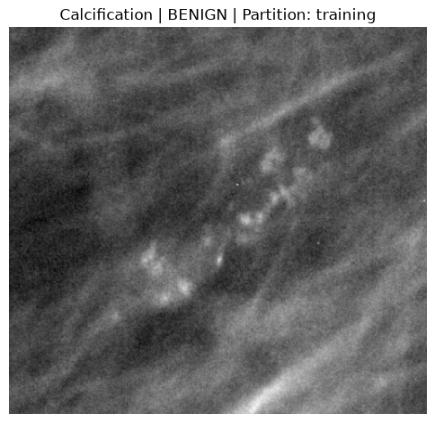

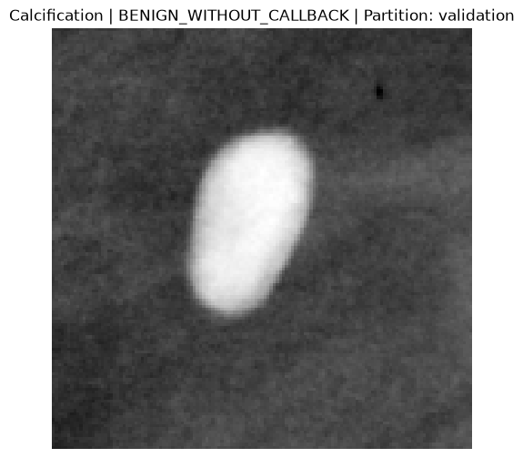

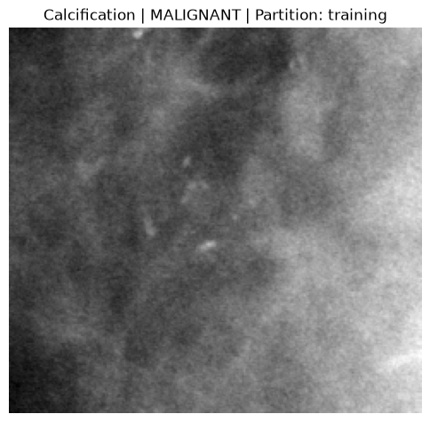

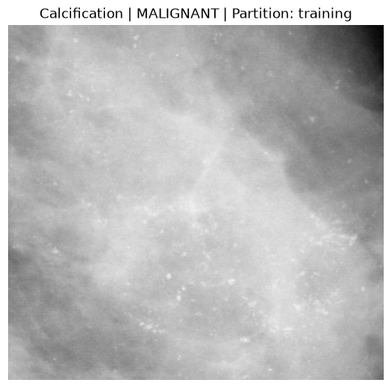

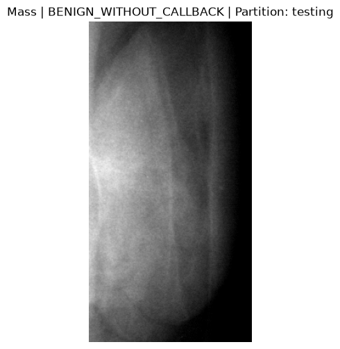

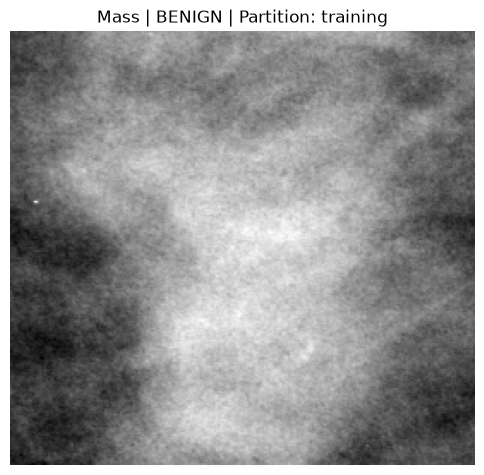

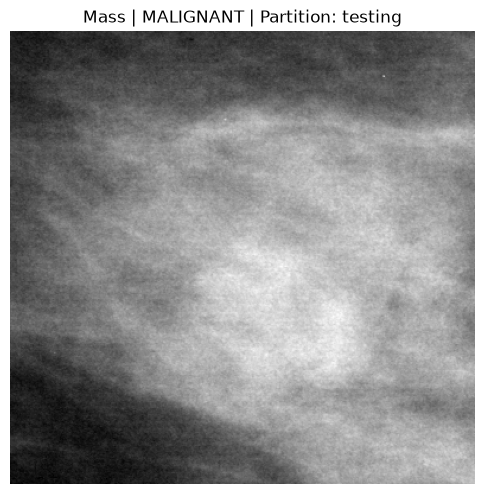

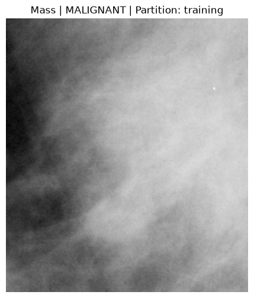

```python
#display every image selected for visal inspection
for _, row in visual_audit_sample.iterrows():

    #read the DICOM file and decode its pixel array
    dicom = pydicom.dcmread(
        row["resolved_dicom_path"]
    )

    pixel_array = dicom.pixel_array

    #invert MONOCROME1 images so that larger displayed values correspond to brighter regions
    if (
        getattr(
            dicom,
            "PhotometricInterpretation",
            ""
        ) == "MONOCHROME1"
    ):
        pixel_array = (
            pixel_array.max()
            - pixel_array
        )

    #display the original cropped image
    plt.figure(
        figsize=(6, 6)
    )

    plt.imshow(
        pixel_array,
        cmap="gray"
    )

    plt.title(
        (
            f"{row['abnormality_group'].title()} | "
            f"{row['pathology']} | "
            f"Partition: {row['final_partition']}"
        )
    )

    plt.axis("off")
    plt.show()
```

**Visual Audit Interpretation**

The sampled files appear to be mammographic images rather than binary ROI masks. The audit also demonstrates considerable variation in crop size, contrast, tissue density and lesion conspicuity.

Calcification cases generally contain small bright foci, ranging from concentrated clusters to more diffuse patterns. Mass cases show broader regions of altered tissue density, with differences in shape, boundary definition and surrounding tissue. Some lesions are visually prominent, whereas others are subtle and poorly separated from adjacent breast tissue.

The samples also vary in how tightly the abnormality is cropped. Some images contain a focused lesion-centred region, while others retain substantially more surrounding tissue. This heterogeneity supports the use of consistent intensity normalisation and aspect-ratio-preserving resizing.

Visual inspection cannot determine whether the pathology labels are clinically correct or whether the crop contains the complete lesion. It provides a technical quality check rather than a radiological assessment.

**Visual Audit Conclusion**

The visual audit confirmed that the sampled model inputs were cropped mammographic images representing both abnormality groups and pathology cases. No obvious ROI masks, empty images or unreadable files were observed. The substantial variation in lesion size, visibility, crop extent and background tissue reinforces the need for standardised preprocessing. However, because this was a limited visual sample and no radiologist reviewed the images, the audit should be interpreted as a technical quality assessment rather than evidence of clinical validity.

### 6.5 Small-Image Assessment

Images with at least one spatial dimension below 100 picels are examined separately. These records are not removed automatically because small dimensions may reflect tightly cropped lesion regions rather than corrupted or incomplete files.

```python
#identify images with a height or width below 100 pixels
small_images = combined_metadata[
    (
        combined_metadata[
            "image_height"
        ] < 100
    )
    |
    (
        combined_metadata[
            "image_width"
        ] < 100
    )
]

print(
    "Images with at least one dimension below 100 pixels:",
    len(small_images)
)

#display a sample for inspection
display(
    small_images[
        [
            "record_id",
            "abnormality_group",
            "image_height",
            "image_width",
            "pathology"
        ]
    ]
    .head(20)
)
```

```
Images with at least one dimension below 100 pixels: 77
```

|  | record_id | abnormality_group | image_height | image_width | pathology |
| --- | --- | --- | --- | --- | --- |
| 16 | calcification_P_00008_RIGHT_MLO_2 | calcification | 105 | 97 | BENIGN_WITHOUT_CALLBACK |
| 324 | calcification_P_00455_LEFT_MLO_3 | calcification | 113 | 97 | BENIGN_WITHOUT_CALLBACK |
| 345 | calcification_P_00476_LEFT_CC_1 | calcification | 105 | 81 | BENIGN_WITHOUT_CALLBACK |
| 347 | calcification_P_00476_RIGHT_CC_1 | calcification | 89 | 89 | BENIGN_WITHOUT_CALLBACK |
| 348 | calcification_P_00476_RIGHT_CC_2 | calcification | 89 | 97 | BENIGN_WITHOUT_CALLBACK |
| 349 | calcification_P_00476_RIGHT_CC_3 | calcification | 89 | 73 | BENIGN_WITHOUT_CALLBACK |
| 352 | calcification_P_00476_RIGHT_MLO_3 | calcification | 97 | 97 | BENIGN_WITHOUT_CALLBACK |
| 370 | calcification_P_00505_LEFT_CC_1 | calcification | 113 | 97 | BENIGN_WITHOUT_CALLBACK |
| 373 | calcification_P_00505_RIGHT_CC_1 | calcification | 97 | 121 | BENIGN_WITHOUT_CALLBACK |
| 375 | calcification_P_00505_RIGHT_MLO_1 | calcification | 97 | 97 | BENIGN_WITHOUT_CALLBACK |
| 377 | calcification_P_00506_RIGHT_CC_1 | calcification | 89 | 105 | BENIGN_WITHOUT_CALLBACK |
| 404 | calcification_P_00529_RIGHT_CC_2 | calcification | 89 | 97 | BENIGN_WITHOUT_CALLBACK |
| 413 | calcification_P_00538_RIGHT_CC_1 | calcification | 89 | 89 | BENIGN_WITHOUT_CALLBACK |
| 415 | calcification_P_00538_RIGHT_MLO_1 | calcification | 105 | 97 | BENIGN_WITHOUT_CALLBACK |
| 417 | calcification_P_00539_RIGHT_CC_2 | calcification | 113 | 89 | MALIGNANT |
| 420 | calcification_P_00539_RIGHT_MLO_2 | calcification | 73 | 97 | MALIGNANT |
| 421 | calcification_P_00539_RIGHT_MLO_3 | calcification | 81 | 89 | MALIGNANT |
| 422 | calcification_P_00539_RIGHT_MLO_4 | calcification | 81 | 97 | MALIGNANT |
| 505 | calcification_P_00635_LEFT_CC_1 | calcification | 161 | 77 | BENIGN_WITHOUT_CALLBACK |
| 587 | calcification_P_00744_RIGHT_CC_1 | calcification | 105 | 81 | BENIGN_WITHOUT_CALLBACK |

```python
#calculate the proportion of small images
small_image_percentage = (
    len(small_images)
    / len(combined_metadata)
    * 100
)

print(
    "Small-image percentage:",
    f"{small_image_percentage:.2f}%"
)
```

```
Small-image percentage: 2.16%
```

**Output Interpretation**

Seventy-seven images, representing 2.16% of the dataset, contained at least one dimension below 100 pixels. The displayed records were predominantly tightly cropped calcification cases rather than unreadable or incorrect resolved files. These images were retained to avoid unnecessary data loss and potential changes to the class or abnormality-group distributions.

All retained images subsequently undergo the same deterministic resizing and normalisation procedure.

### 6.6 Preprocessing Configuration

Following image-quality assessment, a standardised preprocessing pipeline is defined for model development. The original images vary substantially in spatial dimensions and intensity ranges. Each image is therefore transformed into a consistent numerical and spatial representation before being supplied to the models.

The pipeline performs:

1. DICOM pixel-array decoding;
2. Conversion to 32-bit floating-point format;
3. Percentile-based intesity clipping;
4. Intensity scaling to [0,1];
5. Resizing to 224 x 224 pixels;
6. Grayscale-to-three-channel conversion for compatibility with ImageNet-pretrained architectures.

The same deterministic preprocessing is applied to training, validation and testing data. Random data augmentation is introduced separately and applied only to the training partition.

```python
#spatial dimensions required by the model inputs
TARGET_IMAGE_SIZE = (
    224,
    224
)

#percentiles used for robust intensity clipping
LOWER_PERCENTILE = 1.0
UPPER_PERCENTILE = 99.0

#convert the grayscale images to three channels
OUTPUT_CHANNELS = 3

print(
    "Target image size:",
    TARGET_IMAGE_SIZE
)

print(
    "Intensity clipping percentiles:",
    LOWER_PERCENTILE,
    "to",
    UPPER_PERCENTILE
)

print(
    "Output channels:",
     OUTPUT_CHANNELS
)
```

```
Target image size: (224, 224)
Intensity clipping percentiles: 1.0 to 99.0
Output channels: 3
```

**Configuration Interpretation**

All images will be converted to a uniform 224 x 224 x 3 representation. Percentile clipping limits the influence of extreme intensity values, while three-channel conversion allows grayscale mammograms to be used with ImageNet-pretrained architectures.